# Using plantcomNGPN R pkg.

### Using the `plantcomNGPN` R package

### This website has been moved to https://doi-nps.github.io/plantcomNGPN and will no longer be updated on this site. The code repo for this site is https://github.com/DOI-NPS/plantcomNGPN.

#### 1. Setup

##### Overview

The `plantcomNGPN` package was designed to help compile, query and summarize plant community monitoring data collected by the Northern Great Plains Inventory and Monitoring Network (NGPN) data and stored in the FFI (FEAT/FIREMON Integrated) database.

There are a couple of ways to import NGPN FFI data into R, and which will be demonstrated in code below:

##### Import FFI tables from a local database installation in SQL Server Management Studio (SSMS).

1. This approach requires having SQL Server Express installed, which is not available in Software Center and requires elevated privileges from IT to install. SQL Server Express may prohibited in the near future. This approach involves restoring the .bak files, which are exports of the FFI database for each park from the SQL Server database, as a local database copy on a given computer. See **SSMS > Local SSMS** tab for setup instructions. Once that’s completed, continue to R package setup.

##### Import FFI tables from SQL Server.

2. Ideally this will be the main way that NGPN staff import FFI data into R, as it will be importing live data, allowing for real-time QAQC, fixing any errors found, then rerunning the import. Likely each user will need permissions set on the server with their Active Directory account (so NPS or NPS-partners only). SSMS will need to be installed, which is available in Software Center, but SQL Server Express isn’t needed. We will continue to request this access through MB and/or FFI developers until we have it. See **SSMS > Server SSMS** tab for setup instructions. Once that’s completed, continue to R package setup.

##### Import csvs of FFI database tables.

3. The `importData()` function in this package can export a zip file containing csvs of all of the raw FFI database tables. Once that zip file is created, it can be used to import FFI data without the need of SSMS or SQL Server Express. This option allows non-NPS users to work with NPGN data. If this is the option you’re using, go to **R package setup** tab for details on R package installation and setup.

##### Import csvs of the FFI views.

4. In addition to importing and exporting FFI tables, the `importData()` function compiles the FFI raw tables into flattened stand-alone views of each FFI protocol (e.g. Cover Points, Density Belts, Trees, etc.), which are used by package functions to further query, summarize, and visualize the data. The views can be exported as a zip file in the `importData()` function. The zip file of views can be imported via `importViews()` function. This option is the fastest way to import NPGN data into R, and allows non-NPS users to more easily work with NPGN data. These views are intended to be analysis-ready. Any feedback on how to improve their usability is welcome. If this is the option you’re using, go to **R package setup** tab for details on R package installation and setup.

Currently, only import and getter functions exist in the R package. In time, more features will be added, such as functions that perform common summaries and visualize data, and this tutorial will be updated accordingly. Feedback is always welcome on how to improve this tutorial and the R package in general.

Additionally, an automated QC report that checks NPGN FFI data for potential missing data and errors is being developed separately.

##### SSMS

###### Local SSMS

Once this step is complete, users can import FFI database tables into R using the `importData()` function and the name of the database in SSMS (see ImportData tab).

##### Step 1. Install SQL Server Management Studio

Instructions for installing SQL Server Management Studio (SSMS) are currently being developed. Once those are ready, they will be linked here. The best directions currently (though a few years out of date and only accessible by DOI users) can be found here: [SOP_SQLServer_Setup.docx](https://doimspp-my.sharepoint.com/:w:/g/personal/kmmiller_nps_gov/ET6yKk-t50pPqDGm4m15hdkB11Pimv8AvKEC54dEo8PjPA?e=nCCm8u).

##### Step 2. Restore database from .bak file in SSMS

To restore a database from a .bak file in SSMS, you can either restore through the file menu following the screencast or run the SQL code in SSMS below.

**File Menu option:**

[video not shown]

**SQL Code option:** The SQL code below will restore a .bak file to a database named “FFI_RA_AGFO”. To use the code below, you only need to change “FFI_RA_AGFO” to match the name of your database (i.e., whatever precedes the .bak in the file name), and change the C:\temp\path to the path where your .bak file lives. Note that files on OneDrive often cause issues. It’s best to restore from locations directly on your C:\ drive or a server.

```sql
-- Variables to declare and modify for different database name and file locations
DECLARE @DBNAME NVARCHAR(MAX) = 'FFI_RA_AGFO'
DECLARE @FilePathOrig NVARCHAR(MAX) = 'C:\\temp\\'
DECLARE @FilePathNew NVARCHAR(MAX) = 'C:\\Program Files\\Microsoft SQL Server\\MSSQL15.SQLEXPRESS\\MSSQL\\DATA\\';
DECLARE @SQL NVARCHAR(MAX);

-- Run remaining query to restore database
--USE [master]

DECLARE @DATA NVARCHAR(MAX) = @FilePathNew + @DBNAME + '.mdf';
DECLARE @LOG NVARCHAR(MAX) = @FilePathNew + @DBNAME + '.ldf';
DECLARE @DBFULLPATH NVARCHAR(MAX) = @FilePathOrig + @DBNAME + '.bak';
DECLARE @DBLOG NVARCHAR(MAX) = @DBNAME + '_log';

USE[master]

SET @SQL =
  ' RESTORE DATABASE ['+@DBNAME+'] FROM DISK = '''+@DBFULLPATH+''' WITH FILE = 1, MOVE '''+@DBNAME+''' TO '''+@DATA+''',
    MOVE '''+@DBLOG+''' TO '''+@LOG+''',
    NOUNLOAD, STATS = 5'
EXEC(@SQL)
GO
```

###### Server SSMS

[figure not shown]

…hopefully

##### R package setup

If you’ve never installed an R package from GitHub, you’ll need to complete the following steps to install the plantcomNGPN R package. Once completed, move on to the ImportData and other function tabs for instructions on using the R package.

##### Step 1. Install R, RStudio, and RTools44 in Software Center

RTools is needed to install R packages from GitHub via devtools, and it only works with R versions 4.4.x. While R 4.5 is available on Software Center, the matching RTools45 isn’t available as of 8/20/25. Until that changes, link RStudio to the latest version of R 4.4 (I’m currently using R 4.4.3).

##### Step 2. Set RTools44 path

Unfortunately Software Center installs RTools44 in C:/Program Files/, not C:/, which is where RStudio looks for it by default. The following code helps RStudio find RTools. You may occasionally have to rerun this code (except for the `usethis` line), so keep it handy. You know when you have to rerun the code when you try to rebuild a package, and a window pops up to ask if you want to install missing build files.  
RTools step 1. Install the `usethis` package if you don’t already have it installed.

```r
install.packages('usethis')
```

RTools step 2. Open the .Renviron file by running the line of code below.

```r
usethis::edit_r_environ()
```

RTools step 3. Copy the following text and paste it into the .Renviron file, save, then close/reopen RStudio. You don’t need to run anything for this step. Copy/paste are all you need to do.

```r
Sys.setenv(PATH = paste("C:\\PROGRA~1\\Rtools44\\bin", Sys.getenv("PATH"), sep=";"))
Sys.setenv(BINPREF = "C:\\PROGRA~1\\Rtools44\\mingw_$(WIN)\\bin\\")
```

##### **Step 3.** Install devtools package in R:

```r
install.packages('devtools')
```

Once you’ve successfully completed Steps 1-3, you should only have to repeat them if you have a new computer or if you move to R 4.5 or higher (note: R 4.5 will require installing RTools45).

##### Step 4. Set up GitHub account if a new user

To install R packages using `devtools`, you need to have a GitHub user account and active token. Instructions for setting up a GitHub account and connecting it to RStudio are on the [IMD Advanced R training website](https://katemmiller.github.io/IMD_R_Training_Advanced/) from 2022. Go to Day 4: Version Control > Git and RStudio and complete the steps described. There’s a lot of other good info on using GitHub in other tabs too.

##### Step 5. Install `plantcomNGPN` from GitHub

**You must have a GitHub login and be logged into GitHub to install packages from GitHub and for this step to work**

Whenever the `plantcomNGPN` package is updated, you can rerun this code to install the latest version.

```r
library(devtools)
install_github("KateMMiller/plantcomNGPN")
```

##### Troubleshooting GitHub package installation

If you’re unable to install the R package via GitHub (often an error about permission being denied, or cannot open URL, download the following script from my OneDrive and open it in R: [fix_TLS_inspection.R](https://doimspp-my.sharepoint.com/:u:/g/personal/kmmiller_nps_gov/ETaknusoEfVOs9tbIbx6QYEBre0WI-_xxi-C0M3JCX_xfw?e=n00UCO). Download by left clicking on the link, then click in the download arrow in the top left of the screen. Save it to your machine, then open it in RStudio.

Once this script is open in R Studio, press Control + A to select all of the code. Then Control + Enter to run all of the code. Assuming you don’t return any errors, you should be able to install from GitHub. Now try to reinstall `plantcomNGPN`. If you’re still running into issues, it could be that `devtools` is missing some package dependencies, which the error message will often mention. Install any missing packages and then try installing plantcomNGPN again. If you’re still not successful, send Kate Miller (kathryn_miller@nps.gov) a screenshot of the error and she’ll help you troubleshoot.

##### Step 6. Load plantcomNGPN R package

```r
library(plantcomNGPN)
```

#### 2. R package Intro

##### Overview

Once you have the R package installed, you can import and start working with the data. There are 2 import functions in the plantcomNGPN package:

- **importData()**: imports raw FFI tables as individual data frames, either from SSMS or as a zip file of csvs. If multiple databases are specified in the import, the tables will be rowbinded across parks. This function also includes features to export data as a zip file of csvs, which can then be used in the following function.
- **importViews()**: a streamlined function that imports a zip file of flattened views for each FFI protocol.

Once FFI data are imported, the package has a getter function specific to each FFI protocol view that you can use to query the data by parks, years, monitoring status, or purpose. Eventually, there will be summary and plotting functions to work with each protocol.

##### importData()

By default, the `importData()` function imports FFI tables and only returns the flattened views as data frames in an environment called *VIEWS_NGPN*. This minimizes memory usage and keeps a tidy R workspace. R package functions are then designed to work seamlessly with the views, regardless of whether they’re in the VIEWS_NGPN environment or global environment. See **Working with the data** tab for how to work with data.frames housed within the VIEWS_NGPN environment.

- Import data for 1 database using local install in SSMS

  ```r
  library(plantcomNGPN)
  importData(dbname = "FFI_RA_AGFO")
  ```

- Import data for multiple databases using local installs in SSMS

  The code below will bind like data/tables across parks together to have 1 large view

  ```r
  importData(type = 'local',
             dbname = c("FFI_RA_AGFO", "FFI_RA_BADL", "FFI_RA_DETO", "FFI_RA_FOLA",
                        "FFI_RA_FOUS", "FFI_RA_JECA", "FFI_RA_KNRI", "FFI_RA_MNRR",
                        "FFI_RA_MORU", "FFI_RA_SCBL", "FFI_RA_THRO", "FFI_RA_WICA"))
  ```

- Import FFI tables as zip

  The code below will import a zip file of THRO data exported by the `importData()` function (see options below). This approach does not require SSMS to be installed.

  ```r
  importData(type = 'csv', import_path = "C:/temp/FFI_RA_THRO.zip")
  ```

##### importViews()

- Import FFI views as a zip

  The `importViews()` function is the fastest and least memory hungry way to import FFI data. Someone will have to have generated the views by first importing raw FFI tables, and then exporting the views. Once that’s completed, this import function is recommended.

  ```r
  importViews(import_path = "C:/temp/NGPN_FFI_views_20250710.zip")
  ```

##### importData() Options

Export tables or views to zip files.

- Export FFI tables to zip

  If you want to export the raw tables into a zip file of csvs, simply add `export_tables = T`. If no export_path is specified, the zip file will be saved in your working directory. The file name and path of the zip file will be printed in your console. Note that exporting can be slow, especially if you loaded multiple databases.

  ```r
  importData(type = 'local',
             dbname = c("FFI_RA_AGFO", "FFI_RA_BADL", "FFI_RA_DETO", "FFI_RA_FOLA",
                        "FFI_RA_FOUS", "FFI_RA_JECA", "FFI_RA_KNRI", "FFI_RA_MNRR",
                        "FFI_RA_MORU", "FFI_RA_SCBL", "FFI_RA_THRO", "FFI_RA_WICA"),
             export_tables = T, export_path = "C:/temp/")
  ```

- Export views to zip

  Even better, is exporting the views into a zip file of csvs. To do that, add `export_views = T`. If no export_path is specified, the zip file will be saved in your working directory. The file name and path of the zip file will be printed in your console. This zip file is then the fastest way to import FFI data into R using the `importViews()` function instead.

  ```r
  importData(type = 'local',
             dbname = c("FFI_RA_AGFO", "FFI_RA_BADL", "FFI_RA_DETO", "FFI_RA_FOLA",
                        "FFI_RA_FOUS", "FFI_RA_JECA", "FFI_RA_KNRI", "FFI_RA_MNRR",
                        "FFI_RA_MORU", "FFI_RA_SCBL", "FFI_RA_THRO", "FFI_RA_WICA"),
             export_views = T, export_path = "C:/temp")
  ```

- Return raw tables too

  There are times when it helps to view the raw FFI data tables, such as for troubleshooting an issue in the R package, or in figuring out where an error in the data was introduced and need to be fixed. To return the raw FFI tables in addition to the views, specify `keep_tables = TRUE`.

  ```r
  importData(type = 'local',
             dbname = c("FFI_RA_AGFO", "FFI_RA_BADL", "FFI_RA_DETO", "FFI_RA_FOLA",
                        "FFI_RA_FOUS", "FFI_RA_JECA", "FFI_RA_KNRI", "FFI_RA_MNRR",
                        "FFI_RA_MORU", "FFI_RA_SCBL", "FFI_RA_THRO", "FFI_RA_WICA"),
             keep_tables = T)
  ```

- Return views to global environment

  ```r
  importData(type = 'local',
             dbname = c("FFI_RA_AGFO", "FFI_RA_BADL", "FFI_RA_DETO", "FFI_RA_FOLA",
                        "FFI_RA_FOUS", "FFI_RA_JECA", "FFI_RA_KNRI", "FFI_RA_MNRR",
                        "FFI_RA_MORU", "FFI_RA_SCBL", "FFI_RA_THRO", "FFI_RA_WICA"),
             new_env = F)
  ```

##### Working with the Data

The functions in the `plantcomNGPN` package are designed to work with the views in *VIEWS_NGPN*, and are the best way to interact with the data to query by park, site, site type, year, parameter, etc. However, if you want to look at the views without using the package functions, you can use the following code.

If you want to use the `print_head()` function that shows output in the markdown, run the code below. This makes the results print cleaner in the markdown report. For your purposes, you can just run: `head(dataframe)`.

```r
print_head <- function(df){
  nrows <- min(6, nrow(df))
  knitr::kable(df[1:nrows,]) |>
    kableExtra::kable_classic(full_width = F, font_size = 12,
                              bootstrap_options = c("condensed"))
}
```

```r
# See list of the views
names(VIEWS_NGPN)
```

```
##  [1] "Disturbance_History"
##  [2] "Cover_Points_metric"
##  [3] "Trees_metric"
##  [4] "SampleEvents"
##  [5] "Density_Belts_metric"
##  [6] "Surface_Fuels_Fine"
##  [7] "Surface_Fuels_1000Hr"
##  [8] "Density_Quadrats_metric"
##  [9] "Cover_Species_Composition"
## [10] "Taxa_Table"
## [11] "Surface_Fuels_Duff"
## [12] "MacroPlots"
```

```r
# Inspect the cover point view
View(VIEWS_NGPN$Cover_Points_metric)

print_head(VIEWS_NGPN$Cover_Points_metric)
```

| MacroPlot_Name | Unit_Name | MacroPlot_Purpose | UTM_X | UTM_Y | UTMzone | Elevation | Azimuth | Aspect | SlopeHill | SlopeTransect | SampleEvent_Date | year | month | doy | Symbol | ITIS_TSN | ScientificName | CommonName | Visited | NumTran | TranLen | NumPtsTran | Offset | Index | Transect | Point | Tape | Order | Height | … |
| --- | --- | --- | --- | --- | --- | --- | --- | --- | --- | --- | --- | --- | --- | --- | --- | --- | --- | --- | --- | --- | --- | --- | --- | --- | --- | --- | --- | --- | --- | --- |
| AGFO_FPCM_031 | AGFO | IM_Intensive | 603302.6 | 4697924 | 13N | 1334.75 | 3 | 93 | 12 | 4 | 2014-05-29 | 2014 | 5 | 149 | CAFI | 39600 | Carex filifolia | threadleaf sedge | TRUE | 2 | 50 | 50 | -0.7 | -2147483647 | 1 | 1 | 0.3 | 1 | 0.14 | … |
| AGFO_FPCM_031 | AGFO | IM_Intensive | 603302.6 | 4697924 | 13N | 1334.75 | 3 | 93 | 12 | 4 | 2014-05-29 | 2014 | 5 | 149 | LITT | NA | Litter | litter | TRUE | 2 | 50 | 50 | -0.7 | -2147483646 | 1 | 2 | 1.3 | 0 | NA | … |
| AGFO_FPCM_031 | AGFO | IM_Intensive | 603302.6 | 4697924 | 13N | 1334.75 | 3 | 93 | 12 | 4 | 2014-05-29 | 2014 | 5 | 149 | HECO26 | 507974 | Hesperostipa comata | needle and thread | TRUE | 2 | 50 | 50 | -0.7 | -2147483645 | 1 | 2 | 1.3 | 1 | 0.15 | … |
| AGFO_FPCM_031 | AGFO | IM_Intensive | 603302.6 | 4697924 | 13N | 1334.75 | 3 | 93 | 12 | 4 | 2014-05-29 | 2014 | 5 | 149 | CAFI | 39600 | Carex filifolia | threadleaf sedge | TRUE | 2 | 50 | 50 | -0.7 | -2147483644 | 1 | 2 | 1.3 | 2 | NA | … |
| AGFO_FPCM_031 | AGFO | IM_Intensive | 603302.6 | 4697924 | 13N | 1334.75 | 3 | 93 | 12 | 4 | 2014-05-29 | 2014 | 5 | 149 | LITT | NA | Litter | litter | TRUE | 2 | 50 | 50 | -0.7 | -2147483643 | 1 | 3 | 2.3 | 0 | NA | … |
| AGFO_FPCM_031 | AGFO | IM_Intensive | 603302.6 | 4697924 | 13N | 1334.75 | 3 | 93 | 12 | 4 | 2014-05-29 | 2014 | 5 | 149 | CAFI | 39600 | Carex filifolia | threadleaf sedge | TRUE | 2 | 50 | 50 | -0.7 | -2147483642 | 1 | 3 | 2.3 | 1 | 0.19 | … |

```r
# Assign the coverpoint view to the object covpt, which now behaves like a data.frame.
covpt <- VIEWS_NGPN$Cover_Points_metric
```

Additionally, if you want to view the raw FFI data tables, and you imported the data into the NPGN_tables environment, you can access them with the code below:

```r
importData(type = 'local',
           dbname = c("FFI_RA_AGFO", "FFI_RA_BADL", "FFI_RA_DETO", "FFI_RA_FOLA",
                      "FFI_RA_FOUS", "FFI_RA_JECA", "FFI_RA_KNRI", "FFI_RA_MNRR",
                      "FFI_RA_MORU", "FFI_RA_SCBL", "FFI_RA_THRO", "FFI_RA_WICA"),
           keep_tables = T)

# See list of FFI tables
sort(names(NGPN_tables))

# Inspect the MacroPlot table
View(NGPN_tables$MacroPlot)

# Assign the MacroPlot table to the object macro
macro <- NGPN_tables$MacroPlot
```

#### **Getting (and improving) help**

The functions in `plantcomNGPN` have help documentation like any R package. To view the help, you can go to the Packages tab and click on plantcomNGPN (see below). That will show you all the functions in the package. Clicking on individual functions will take you to the help documentation for that function.

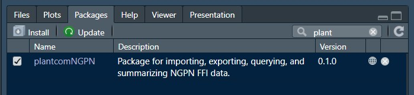

You can also see the help of a function by running, for example:

```r
?importData
```

If `plantcomNGPN` isn’t loaded yet, you’d run:

```r
?plantcomNGPN::importData
```

Each function’s help includes a Description, Usage (i.e. function arguments and their defaults), Argument options/definitions, and several examples showing how the function can be used.

**This is where you come in! If you notice typos or can think of better descriptions, examples, error messages, etc., please send them my way!** After we’re more comfortable with R packages and get versed on GitHub, you’ll be able to make those changes directly in the package. For now, you can just send me your suggestions and I’ll make the changes.

Finally, if you ever want to peak under the hood at the function, you can view it several ways.

1. Keep F2 key pressed and click on the function name in R. This trick works for many but not all functions in R.
2. View code in the [GitHub katemmiller/plantcomNGPN repo](https://github.com/KateMMiller/plantcomNGPN/tree/main). The functions are in the R folder.

#### 3. getter Functions

##### getMacroPlot()

This function filters FFI macroplot data by park, plot name, project, and purpose. This function was primarily developed to pull out NGPN plant community monitoring plots. Using combinations of plot names, projects or purposes that are outside NGPN PCM plots hasn’t been tested as thoroughly, and may not return intended results in every case. Note that this is more of an internal function that other data-related getter functions source to efficiently filter on records.

Return all NGPN Plant Community Monitoring plots (ie vital signs plots), for the Park stratum and all purposes used by NGPN

```r
macro_vs <- getMacroPlot()
print_head(macro_vs)
```

|  | MacroPlot_Name | Unit_Name | MacroPlot_Purpose | MacroPlot_Type | ProjectUnit_Park | Agency | UTM_X | UTM_Y | UTMzone | Datum | DD_Lat | DD_Long | Elevation | ElevationUnits | Azimuth | Aspect | SlopeHill | SlopeTransect | StartPoint | Directions | MacroPlot_Comment | MacroPlot_UV1 | MacroPlot_UV2 | MacroPlot_UV3 | MacroPlot_UV4 | MacroPlot_UV5 | MacroPlot_UV6 | MacroPlot_UV7 | MacroPlot_UV8 | … |
| --- | --- | --- | --- | --- | --- | --- | --- | --- | --- | --- | --- | --- | --- | --- | --- | --- | --- | --- | --- | --- | --- | --- | --- | --- | --- | --- | --- | --- | --- | --- |
| 1 | AGFO_FPCM_031 | AGFO | IM_Intensive | Grassland | 1 | NPS | 603302.6 | 4697924 | 13N | NAD83 | NA | NA | 1334.750 | meters | 3 | 93 | 12 | 4 | Park at service road entrance, off paved road | Hike along two-track/service road; plot is west and uphill. Use GPS | center point moved (note from GPS unit: plot center moved 10 paces at 275 deg from grts.) | LS | >50m | UP | UG | NA | NA | NA | River North | … |
| 2 | AGFO_FPCM_036 | AGFO | IM_Intensive | Grassland | 1 | NPS | 604500.0 | 4696307 | 13N | NAD83 | NA | NA | 1356.051 | meters | 161 | 251 | 20 | 5 | Drive in past Hoffman House along 2-track towards South park boundary. Park vehicle along 2-track when close to plot (about 230m). | Plot is approx. 230m ENE of the vehicle/2-track. Plot is on westerly hillside, past drainage. | NA | US | >50m | UP | UG | NA | NA | NA | CARNEGIE | … |
| 4 | AGFO_FPCM_044 | AGFO | IM_Intensive | Grassland | 1 | NPS | 603154.4 | 4696791 | 13N | NAD83 | NA | NA | 1333.450 | meters | 352 | 82 | 15 | 5 | NA | NA | NA | MS | >50m | UP | UG | NA | NA | NA | River South | … |
| 5 | AGFO_FPCM_057 | AGFO | IM_Intensive | Grassland | 1 | NPS | 599810.3 | 4698351 | 13N | NAD83 | NA | NA | 1366.049 | meters | 84 | 174 | 10 | 4 | Daemonelix hiking path parking lot. | Hike Daemonelix Trail towards end of trail. Plot is west of Daemonelix “telephone booth” display on hillside. | NA | US | >50m | UP | UG | NA | NA | NA | Daemonelix | … |
| 7 | AGFO_FPCM_060 | AGFO | IM_Intensive | Grassland | 1 | NPS | 603532.6 | 4696676 | 13N | NAD83 | NA | NA | 1351.450 | meters | 273 | 3 | 21 | 6 | Park at Hoffman House, or nearby on 2-track | Use GPS to navigate to plot which is located sideslope | NA | MS | >50m | UP | UG | NA | NA | NA | River South | … |
| 8 | AGFO_FPCM_061 | AGFO | IM_Intensive | Grassland | 1 | NPS | 600083.6 | 4697596 | 13N | NAD83 | NA | NA | 1330.149 | meters | 308 | 38 | 1 | 2 | Park on side of road parallel with telephone pole immediately to West of old riparian oxbow. | Locate telephone pole and walk ten meters north. | 5/28/15 - plot was retired for Fire Effects purposes. Determined to not be representative of Rx Unit vegetation (#12 Does not meet stratum definition on Site Evaluation Checklist), due to the high num… | LV | >50m | TF | UG | NA | NA | NA | NA | … |

Return Prairie stratum for SCBL for NGPN_PCM plots

```r
macro_pr_vs <- getMacroPlot(park = "SCBL", project = "Prairie")
print_head(macro_pr_vs)
```

|  | MacroPlot_Name | Unit_Name | MacroPlot_Purpose | MacroPlot_Type | ProjectUnit_Prairie | Agency | UTM_X | UTM_Y | UTMzone | Datum | DD_Lat | DD_Long | Elevation | ElevationUnits | Azimuth | Aspect | SlopeHill | SlopeTransect | StartPoint | Directions | MacroPlot_Comment | MacroPlot_UV1 | MacroPlot_UV2 | MacroPlot_UV3 | MacroPlot_UV4 | MacroPlot_UV5 | MacroPlot_UV6 | MacroPlot_UV7 | MacroPlot_UV8 | … |
| --- | --- | --- | --- | --- | --- | --- | --- | --- | --- | --- | --- | --- | --- | --- | --- | --- | --- | --- | --- | --- | --- | --- | --- | --- | --- | --- | --- | --- | --- | --- |
| 506 | SCBL_PCM_0002 | SCBL | Panel1 | NA | 1 | NPS | 605735.0 | 4630811 | 13N | NAD83 | 41.82212 | -103.7268 | 1288.866 | meters | 154 | 244 | 15 | 7 | SCBL staff can gain access to private ranch road W of park. This allows you to drive w/in 800m of plot. | Hike SSW ~800 meters to plot. | Some juniper and ponderosa pine in plot. Potential for both grass and forest reads. We DID NOT install T1 or T2 nail washers. (6/3/2010) T1 and T2 washers installed 6/7/11 | \|MS | \|>50m | \|UP | \|UG | \|NA | \|NA | \|1 | \|South Bluff | … |
| 507 | SCBL_PCM_0004 | SCBL | Panel1 | NA | 1 | NPS | 607617.9 | 4629997 | 13N | NAD83 | 41.81454 | -103.7043 | 1293.466 | meters | 50 | 140 | 16 | 2 | Park on north side of irrigation ditch near park gate (green metal gate) | Go west (~270 degrees) | NA | MS | >50m | UP | UG |  | NA | 1 | Crown Rock | … |
| 508 | SCBL_PCM_0005 | SCBL | Panel2 | NA | 1 | NPS | 606974.8 | 4630914 | 13N | NAD83 | 41.82289 | -103.7119 | 1291.566 | meters | 338 | 68 | 27 | 11 | Visitor Center. The vehicle can stay in the visitor parking lot until dusk. | Walk straight up to it, ~700 m. Tag and nail on T2F not installed! Washer should be in the folder. | \|Tag T2F not installed! Washer is in the folder. PRVI in plot, no other trees or tall shrubs. | \|US | \|>50m | \|UP | \|UG | \|NA | \|NA | \|2 | \|Crown Rock | … |
| 509 | SCBL_PCM_0006 | SCBL | Panel2 | NA | 1 | NPS | 606219.1 | 4633928 | 13N | NAD83 | 41.85013 | -103.7204 | 1206.965 | meters | 245 | 335 | 3 | 1 | Parked at gate of park & canal road (the plot is closer to a private home, but chose to park on NPS property and walk farther). | Walk ~500 through prairie dog town after using foot bridge to cross canal. | Prairie dog town | LS | >50 | UP | UG | NA | NA | 2 | Prairie | … |
| 510 | SCBL_PCM_0007 | SCBL | Panel2 |  | 1 | NPS | 607674.9 | 4633443 | 13N | NAD83 | 41.84557 | -103.7030 | 1229.166 | m | 170 | 260 | 11 | 1 | Parking spot on canal road near foot bridge, 100m inside park gate. | Cross foot bridge, follow canal east to drainage and walk up. | NA | MS | >50m | UP | UG | NA | NA | 2 | Prairie | … |
| 511 | SCBL_PCM_0009 | SCBL | Panel3 | NA | 1 | NPS | 607028.4 | 4631993 | 13N | NAD83 | 41.83259 | -103.7110 | 1272.966 | meters | 192 | 282 | 5 | 1 | Park @ visitor center | Walk up trail past visitor center, past oxen, ~5 minutes head off trail ~100 feet to plot. Hike west on Old Oregon Trail past replica oxen and wagon. Continue on trail through two weak switchbacks. He… |  |  |  |  |  |  |  |  |  | … |

Query NGPN only plots from North Dakota

```r
macro_nd <- getMacroPlot(park = c("FOUS", "KNRI", "THRO"))
print_head(macro_nd)
```

|  | MacroPlot_Name | Unit_Name | MacroPlot_Purpose | MacroPlot_Type | ProjectUnit_Park | Agency | UTM_X | UTM_Y | UTMzone | Datum | DD_Lat | DD_Long | Elevation | ElevationUnits | Azimuth | Aspect | SlopeHill | SlopeTransect | StartPoint | Directions | MacroPlot_Comment | MacroPlot_UV1 | MacroPlot_UV2 | MacroPlot_UV3 | MacroPlot_UV4 | MacroPlot_UV5 | MacroPlot_UV6 | MacroPlot_UV7 | MacroPlot_UV8 | … |
| --- | --- | --- | --- | --- | --- | --- | --- | --- | --- | --- | --- | --- | --- | --- | --- | --- | --- | --- | --- | --- | --- | --- | --- | --- | --- | --- | --- | --- | --- | --- |
| 304 | FOUS_PCM_001 | FOUS | Panel1 |  | 1 | NPS | 572425.3 | 5316728 | 13N | NAD83 | NA | NA | 570.099 | meters | 58 | 148 | 0 | 0 | Service road East side of park | \|NA | \|NO TAGS Tags have been installed previously - GAA 7/29/2012 | \|LV | \|>50m | \|UP | \|UG | Tags added 2012 2015 - entire plot mowed in past week. | \|LV | \|>50m | \|UP | … |
| 308 | FOUS_PCM_005 | FOUS | Panel3 | NA | 1 | NPS | 571133.6 | 5316993 | 13N | NAD83 | NA | NA | 569.098 | meters | 90 | 180 | 1 | 1 | Plot is across the road from main park sign. Park @ picnic area or park gate | From parking lot, walk ~200 m up the road | 2011-There weren’t any tags for the plot so it was not installed. However, the site was evaluated and it was accepted. 2012- Determined azimuth in 2012, may differ from 2011 evaluation 2023- Overview … | \|LV | \|>50m | \|UP | \|UG | \|NA | \|NA | \|3 | \|Block 4 | … |
| 309 | FOUS_PCM_006 | FOUS | Panel3 | NA | 1 | NPS | 571780.9 | 5316885 | 13N | NAD83 | NA | NA | 565.698 | meters | 90 | 180 | 1 | 0 | Visitor center parking lot | hike past teepees towards road | Evaluated but not established 2012- mowed 2015 - A line mowed | \|LV | \|>50m | \|UP | \|UG | \|NA | \|NA | \|3 | \|Blocks 5 & 6 | … |

Query and combine North and South Upland for THRO

```r
thro_upn <- getMacroPlot(park = "THRO", project = "North Upland") |>
  select(-ProjectUnit_North_Upland)
thro_ups <- getMacroPlot(park = "THRO", project = "South Upland") |> select(-ProjectUnit_South_Upland)

thro_upn$ProjectUnit <- "North_Upland"
thro_ups$ProjectUnit <- "South_Upland"

thro_up <- rbind(thro_upn, thro_ups)
print_head(thro_up)
```

[output not shown]

[output not shown]

[output not shown]

[output not shown]

[output not shown]

[output not shown]

[output not shown]

[output not shown]

[output not shown]

[output not shown]

[output not shown]

[output not shown]

[output not shown]

[output not shown]

[output not shown]

[output not shown]

[output not shown]

[output not shown]

[output not shown]

[output not shown]

[output not shown]

[output not shown]

[output not shown]

[output not shown]

[output not shown]

[output not shown]

[output not shown]

[output not shown]

[output not shown]

[output not shown]

[output not shown]

[output not shown]

[output not shown]

[output not shown]

[output not shown]

[output not shown]

[output not shown]

[output not shown]

[output not shown]

[output not shown]

[output not shown]

[output not shown]

[output not shown]

[output not shown]

[output not shown]

[output not shown]

[output not shown]

[output not shown]

[output not shown]

[output not shown]

[output not shown]

[output not shown]

[output not shown]

[output not shown]

[output not shown]

[output not shown]

[output not shown]

[output not shown]

[output not shown]

[output not shown]

##### getSampleEvent()

This function filters FFI sample event data by park, plot name, project, purpose, and year. This function was primarily developed to pull out NGPN plant community monitoring plots. Using combinations of plot names, projects or purposes that are outside NGPN PCM plots hasn’t been tested as thoroughly, and may not return intended results in every case. Note that this is more of an internal function that other data-related getter functions source to efficiently filter on records. Note that currently, the MonitoringStatus_Comment column is not included, as it results in duplicate returns, where one row is blank and another includes a comment f or the sample sample event.

Default return all samples of NGPN Plant Community Monitoring plots (ie vital signs plots), for the Park stratum and all purposes used by NGPN from 2011 and later.

```r
samp_vs <- getSampleEvent()
print_head(samp_vs)
```

|  | MacroPlot_Name | Unit_Name | MacroPlot_Purpose | MacroPlot_Type | SampleEvent_Date | year | month | doy | UTM_X | UTM_Y | UTMzone | Elevation | Azimuth | Aspect | SlopeHill | SlopeTransect | SampleEvent_UV1 | DefaultMonitoringStatus | TreatmentUnit | MonitoringStatus_Prefix | MonitoringStatus_Base | MonitoringStatus_Suffix | MonitoringStatus_Name | SampleEvent_Comment | SampleEvent_GUID | RegistrationUnit_GUID | MacroPlot_GUID | ProjectUnit_Name |
| --- | --- | --- | --- | --- | --- | --- | --- | --- | --- | --- | --- | --- | --- | --- | --- | --- | --- | --- | --- | --- | --- | --- | --- | --- | --- | --- | --- | --- |
| 6 | AGFO_FPCM_031 | AGFO | IM_Intensive | Grassland | 2017-05-30 | 2017 | 5 | 150 | 603302.6 | 4697924 | 13N | 1334.750 | 3 | 93 | 12 | 4 | NA | NA | NA | 2017_ | FirePlantCommunity | NA | 2017_FirePlantCommunity | NA | 3891DABC-01CE-4E2A-A21F-9AFBCCB46EF4 | 2CCF3ADD-52AF-4A19-831B-B8A394F850F3 | 7C69F60A-84A6-4E7B-9752-44DF50C43715 | Park |
| 14 | AGFO_FPCM_036 | AGFO | IM_Intensive | Grassland | 2017-06-01 | 2017 | 6 | 152 | 604500.0 | 4696307 | 13N | 1356.051 | 161 | 251 | 20 | 5 | NA | NA | NA | 2017_ | FirePlantCommunity | NA | 2017_FirePlantCommunity | NA | ED8E8E70-2DA1-4026-8815-7E4D7C11FFD3 | 2CCF3ADD-52AF-4A19-831B-B8A394F850F3 | 48F28639-DEDD-4F07-861F-0DC309B10245 | Park |
| 38 | AGFO_FPCM_044 | AGFO | IM_Intensive | Grassland | 2019-06-03 | 2019 | 6 | 154 | 603154.4 | 4696791 | 13N | 1333.450 | 352 | 82 | 15 | 5 | NA | NA | River South | 2019_ | PlantCommunity | NA | 2019_PlantCommunity | NA | B3A743E0-AF9A-4CD5-9A39-CD8F8E8AD638 | 2CCF3ADD-52AF-4A19-831B-B8A394F850F3 | 78AEDCB6-7B5B-4417-9068-32E12B424741 | Park |
| 45 | AGFO_FPCM_057 | AGFO | IM_Intensive | Grassland | 2012-06-04 | 2012 | 6 | 156 | 599810.3 | 4698351 | 13N | 1366.049 | 84 | 174 | 10 | 4 | NA | 01Pre | Daemonelix | 2012_ | FirePlantCommunity | NA | 2012_FirePlantCommunity | NA | 3E81186D-265F-4734-A01A-DD5A3C9D8432 | 2CCF3ADD-52AF-4A19-831B-B8A394F850F3 | 7F3819B1-C640-4996-BF73-D27F49EFACFD | Park |
| 52 | AGFO_FPCM_060 | AGFO | IM_Intensive | Grassland | 2013-06-05 | 2013 | 6 | 156 | 603532.6 | 4696676 | 13N | 1351.450 | 273 | 3 | 21 | 6 | NA | NA | NA | 2013_ | FirePlantCommunity | NA | 2013_FirePlantCommunity | NA | 6D39C054-86A2-4CBB-ADFF-A42A26955B3D | 2CCF3ADD-52AF-4A19-831B-B8A394F850F3 | E1901A13-4BAC-4CDC-9246-3EADC6F6321E | Park |
| 61 | AGFO_FPCM_061 | AGFO | IM_Intensive | Grassland | 2012-06-05 | 2012 | 6 | 157 | 600083.6 | 4697596 | 13N | 1330.149 | 308 | 38 | 1 | 2 | NA | 01Pre | Daemonelix | 2012_ | FirePlantCommunity | NA | 2012_FirePlantCommunity | NA | C383B455-8B65-4E49-B56D-5C28054939B3 | 2CCF3ADD-52AF-4A19-831B-B8A394F850F3 | B46FC108-8BE5-4682-B7C6-213758385EA5 | Park |

Return data for AGFO and SCBL for NGPN_PCM plots

```r
samp_AS <- getSampleEvent(park = c("AGFO", "SCBL"), purpose = "NGPN_PCM")
print_head(samp_AS)
```

|  | MacroPlot_Name | Unit_Name | MacroPlot_Purpose | MacroPlot_Type | SampleEvent_Date | year | month | doy | UTM_X | UTM_Y | UTMzone | Elevation | Azimuth | Aspect | SlopeHill | SlopeTransect | SampleEvent_UV1 | DefaultMonitoringStatus | TreatmentUnit | MonitoringStatus_Prefix | MonitoringStatus_Base | MonitoringStatus_Suffix | MonitoringStatus_Name | SampleEvent_Comment | SampleEvent_GUID | RegistrationUnit_GUID | MacroPlot_GUID | ProjectUnit_Name |
| --- | --- | --- | --- | --- | --- | --- | --- | --- | --- | --- | --- | --- | --- | --- | --- | --- | --- | --- | --- | --- | --- | --- | --- | --- | --- | --- | --- | --- |
| 6 | AGFO_FPCM_031 | AGFO | IM_Intensive | Grassland | 2017-05-30 | 2017 | 5 | 150 | 603302.6 | 4697924 | 13N | 1334.750 | 3 | 93 | 12 | 4 | NA | NA | NA | 2017_ | FirePlantCommunity | NA | 2017_FirePlantCommunity | NA | 3891DABC-01CE-4E2A-A21F-9AFBCCB46EF4 | 2CCF3ADD-52AF-4A19-831B-B8A394F850F3 | 7C69F60A-84A6-4E7B-9752-44DF50C43715 | Park |
| 14 | AGFO_FPCM_036 | AGFO | IM_Intensive | Grassland | 2017-06-01 | 2017 | 6 | 152 | 604500.0 | 4696307 | 13N | 1356.051 | 161 | 251 | 20 | 5 | NA | NA | NA | 2017_ | FirePlantCommunity | NA | 2017_FirePlantCommunity | NA | ED8E8E70-2DA1-4026-8815-7E4D7C11FFD3 | 2CCF3ADD-52AF-4A19-831B-B8A394F850F3 | 48F28639-DEDD-4F07-861F-0DC309B10245 | Park |
| 38 | AGFO_FPCM_044 | AGFO | IM_Intensive | Grassland | 2019-06-03 | 2019 | 6 | 154 | 603154.4 | 4696791 | 13N | 1333.450 | 352 | 82 | 15 | 5 | NA | NA | River South | 2019_ | PlantCommunity | NA | 2019_PlantCommunity | NA | B3A743E0-AF9A-4CD5-9A39-CD8F8E8AD638 | 2CCF3ADD-52AF-4A19-831B-B8A394F850F3 | 78AEDCB6-7B5B-4417-9068-32E12B424741 | Park |
| 45 | AGFO_FPCM_057 | AGFO | IM_Intensive | Grassland | 2012-06-04 | 2012 | 6 | 156 | 599810.3 | 4698351 | 13N | 1366.049 | 84 | 174 | 10 | 4 | NA | 01Pre | Daemonelix | 2012_ | FirePlantCommunity | NA | 2012_FirePlantCommunity | NA | 3E81186D-265F-4734-A01A-DD5A3C9D8432 | 2CCF3ADD-52AF-4A19-831B-B8A394F850F3 | 7F3819B1-C640-4996-BF73-D27F49EFACFD | Park |
| 52 | AGFO_FPCM_060 | AGFO | IM_Intensive | Grassland | 2013-06-05 | 2013 | 6 | 156 | 603532.6 | 4696676 | 13N | 1351.450 | 273 | 3 | 21 | 6 | NA | NA | NA | 2013_ | FirePlantCommunity | NA | 2013_FirePlantCommunity | NA | 6D39C054-86A2-4CBB-ADFF-A42A26955B3D | 2CCF3ADD-52AF-4A19-831B-B8A394F850F3 | E1901A13-4BAC-4CDC-9246-3EADC6F6321E | Park |
| 61 | AGFO_FPCM_061 | AGFO | IM_Intensive | Grassland | 2012-06-05 | 2012 | 6 | 157 | 600083.6 | 4697596 | 13N | 1330.149 | 308 | 38 | 1 | 2 | NA | 01Pre | Daemonelix | 2012_ | FirePlantCommunity | NA | 2012_FirePlantCommunity | NA | C383B455-8B65-4E49-B56D-5C28054939B3 | 2CCF3ADD-52AF-4A19-831B-B8A394F850F3 | B46FC108-8BE5-4682-B7C6-213758385EA5 | Park |

Query all NGPN_PCM sites JECA PlantCommunity only

```r
samp_jeca <- getSampleEvent(park = "JECA", mon_status = "PlantCommunity")
print_head(samp_jeca)
```

|  | MacroPlot_Name | Unit_Name | MacroPlot_Purpose | MacroPlot_Type | SampleEvent_Date | year | month | doy | UTM_X | UTM_Y | UTMzone | Elevation | Azimuth | Aspect | SlopeHill | SlopeTransect | SampleEvent_UV1 | DefaultMonitoringStatus | TreatmentUnit | MonitoringStatus_Prefix | MonitoringStatus_Base | MonitoringStatus_Suffix | MonitoringStatus_Name | SampleEvent_Comment | SampleEvent_GUID | RegistrationUnit_GUID | MacroPlot_GUID | ProjectUnit_Name |
| --- | --- | --- | --- | --- | --- | --- | --- | --- | --- | --- | --- | --- | --- | --- | --- | --- | --- | --- | --- | --- | --- | --- | --- | --- | --- | --- | --- | --- |
| 2514 | JECA_PCM_004 | JECA | Panel2 | Upland | 2012-07-02 | 2012 | 7 | 184 | 594937.7 | 4843209 | 13N | 1661.615 | 258 | 348 | 31 | 9 | PCCSM 1.01 | 2012_PlantCommunity | NA | 2012_ | PlantCommunity | NA | 2012_PlantCommunity | PCM-5: Data sheet for transect A, nest 5, 10m, includes the code “EIAN”. Nobody remembers what this was supposed to be, so I have left it out of the FFI data. –LEB 8/21/12 | 55681FC5-23C3-4EB2-AA49-44FDCF3F5ABB | 7DFFB9AC-590F-43DB-B313-91B52F27118C | 5422ABBF-29AE-4E1A-B16A-91258A17B276 | Park |
| 2516 | JECA_PCM_004 | JECA | Panel2 | Upland | 2013-07-01 | 2013 | 7 | 182 | 594937.7 | 4843209 | 13N | 1661.615 | 258 | 348 | 31 | 9 | PCCSM 1.02 | 2013_PlantCommunity | NA | 2013_ | PlantCommunity | NA | 2013_PlantCommunity | NA | 13BC270E-68F5-4EDB-8418-6CBF9CE9FB63 | 7DFFB9AC-590F-43DB-B313-91B52F27118C | 5422ABBF-29AE-4E1A-B16A-91258A17B276 | Park |
| 2520 | JECA_PCM_004 | JECA | Panel2 | Upland | 2017-07-05 | 2017 | 7 | 186 | 594937.7 | 4843209 | 13N | 1661.615 | 258 | 348 | 31 | 9 | PCCSM 2.1 | 2017_PlantCommunity | NA | 2017_ | PlantCommunity | NA | 2017_PlantCommunity | Trees and Poles: *1267 is a new tree, needs to be added to tree map! | 0E6C565C-52EB-44CA-9E3E-D3EA44AD45CB | 7DFFB9AC-590F-43DB-B313-91B52F27118C | 5422ABBF-29AE-4E1A-B16A-91258A17B276 | Park |
| 2521 | JECA_PCM_004 | JECA | Panel2 | Upland | 2018-07-03 | 2018 | 7 | 184 | 594937.7 | 4843209 | 13N | 1661.615 | 258 | 348 | 31 | 9 | PCCSM 3.0 | 2018_Plant Community | NA | 2018_ | PlantCommunity |  | 2018_PlantCommunity | NA | 9BDBAA4A-EB87-44E9-ADCE-A05E7A39099A | 7DFFB9AC-590F-43DB-B313-91B52F27118C | 5422ABBF-29AE-4E1A-B16A-91258A17B276 | Park |
| 2526 | JECA_PCM_004 | JECA | Panel2 | Upland | 2022-06-29 | 2022 | 6 | 180 | 594937.7 | 4843209 | 13N | 1661.615 | 258 | 348 | 31 | 9 | PCCSM 2022 | NA | NA | 2022_ | PlantCommunity |  | 2022_PlantCommunity | NA | EB02F17D-5915-48F2-9256-E7272A2A9CE9 | 7DFFB9AC-590F-43DB-B313-91B52F27118C | 5422ABBF-29AE-4E1A-B16A-91258A17B276 | Park |
| 2528 | JECA_PCM_004 | JECA | Panel2 | Upland | 2023-06-27 | 2023 | 6 | 178 | 594937.7 | 4843209 | 13N | 1661.615 | 258 | 348 | 31 | 9 | PCCSM 2023 | NA | Lithograph Canyon | 2023_ | PlantCommunity | NA | 2023_PlantCommunity | NA | 1098200A-F1C6-4C12-93BA-F9EA009FC7AA | 7DFFB9AC-590F-43DB-B313-91B52F27118C | 5422ABBF-29AE-4E1A-B16A-91258A17B276 | Park |

Query NGPN only plots from North Dakota from 2020:2024

```r
samp_nd <- getSampleEvent(park = c("FOUS", "KNRI", "THRO"), years = 2020:2024)
print_head(samp_nd)
```

|  | MacroPlot_Name | Unit_Name | MacroPlot_Purpose | MacroPlot_Type | SampleEvent_Date | year | month | doy | UTM_X | UTM_Y | UTMzone | Elevation | Azimuth | Aspect | SlopeHill | SlopeTransect | SampleEvent_UV1 | DefaultMonitoringStatus | TreatmentUnit | MonitoringStatus_Prefix | MonitoringStatus_Base | MonitoringStatus_Suffix | MonitoringStatus_Name | SampleEvent_Comment | SampleEvent_GUID | RegistrationUnit_GUID | MacroPlot_GUID | ProjectUnit_Name |
| --- | --- | --- | --- | --- | --- | --- | --- | --- | --- | --- | --- | --- | --- | --- | --- | --- | --- | --- | --- | --- | --- | --- | --- | --- | --- | --- | --- | --- |
| 2354 | FOUS_PCM_001 | FOUS | Panel1 |  | 2022-07-23 | 2022 | 7 | 204 | 572425.3 | 5316728 | 13N | 570.099 | 58 | 148 | 0 | 0 | PCCSM 2022 | NA | NA | 2022_ | PlantCommunity | NA | 2022_PlantCommunity | NA | 8C29AA90-5208-472E-B5CD-5D721861FE37 | 7227A4BE-98FF-4121-906F-30E59A03C5FD | 5F2A239B-708A-45A8-BA3E-9CC22A42A56D | Park |
| 2363 | FOUS_PCM_002 | FOUS | Panel1 | NA | 2022-07-22 | 2022 | 7 | 203 | 571351.3 | 5316939 | 13N | 566.298 | 47 | 137 | 0 | 0 | PCCSM 2022 | NA | NA | 2022_ | PlantCommunity | NA | 2022_PlantCommunity | NA | 01178B39-B8DA-4874-82A6-DC311DB1E87F | 7227A4BE-98FF-4121-906F-30E59A03C5FD | 16295CF7-277C-4DED-AB80-6C7AB307227D | Park |
| 2377 | FOUS_PCM_003 | FOUS | Panel2 |  | 2022-07-23 | 2022 | 7 | 204 | 572319.8 | 5316776 | 13N | 566.299 | 134 | 224 | 2 | 1 | PCCSM 2022 | NA | NA | 2022_ | PlantCommunity | NA | 2022_PlantCommunity | NA | 5A0BF0DE-F1D5-4325-883B-AFA7AF3C1DE1 | 7227A4BE-98FF-4121-906F-30E59A03C5FD | 879476B6-FAAC-425D-9EE2-8AEB30A556D1 | Park |
| 2378 | FOUS_PCM_003 | FOUS | Panel2 |  | 2023-07-22 | 2023 | 7 | 203 | 572319.8 | 5316776 | 13N | 566.299 | 134 | 224 | 2 | 1 | PCCSM 2023 | NA | NA | 2023_ | PlantCommunity | NA | 2023_PlantCommunity | NA | BFFCEC41-DA00-4BB2-9A2A-8EFD235E011E | 7227A4BE-98FF-4121-906F-30E59A03C5FD | 879476B6-FAAC-425D-9EE2-8AEB30A556D1 | Park |
| 2392 | FOUS_PCM_004 | FOUS | Panel2 |  | 2022-07-23 | 2022 | 7 | 204 | 572317.3 | 5316448 | 13N | 559.399 | 81 | 171 | 1 | 1 | PCCSM 2022 | NA | NA | 2022_ | PlantCommunity | NA | 2022_PlantCommunity | NA | 274FCA4A-17A4-4D94-86C8-A3BD9E6843EA | 7227A4BE-98FF-4121-906F-30E59A03C5FD | 2BC803A0-3F17-44BB-B56C-8CEE1CA88ECE | Park |
| 2393 | FOUS_PCM_004 | FOUS | Panel2 |  | 2023-07-22 | 2023 | 7 | 203 | 572317.3 | 5316448 | 13N | 559.399 | 81 | 171 | 1 | 1 | PCCSM 2023 | NA | NA | 2023_ | PlantCommunity | NA | 2023_PlantCommunity | 7/22/2023 - Center rebar not found | 51853C6A-1FC6-4E5F-B3A6-CAFC90F405DD | 7227A4BE-98FF-4121-906F-30E59A03C5FD | 2BC803A0-3F17-44BB-B56C-8CEE1CA88ECE | Park |

Query and combine North and South Upland for THRO

```r
thro_upn <- getSampleEvent(park = "THRO", project = "North Upland")
thro_upn$ProjectUnit <- "North_Upland"

thro_ups <- getSampleEvent(park = "THRO", project = "South Upland")
thro_ups$ProjectUnit <- "South_Upland"

thro_up <- rbind(thro_upn, thro_ups)

print_head(thro_up)
```

[output not shown]

Return results for three plots in KNRI for PlantCommunity monitoring status only

```r
KNRI_123 <- getSampleEvent(plot_name = c("KNRI_PCM_001", "KNRI_PCM_002", "KNRI_PCM_003"),
  mon_stat = "PlantCommunity")
print_head(KNRI_123)
```

|  | MacroPlot_Name | Unit_Name | MacroPlot_Purpose | MacroPlot_Type | SampleEvent_Date | year | month | doy | UTM_X | UTM_Y | UTMzone | Elevation | Azimuth | Aspect | SlopeHill | SlopeTransect | SampleEvent_UV1 | DefaultMonitoringStatus | TreatmentUnit | MonitoringStatus_Prefix | MonitoringStatus_Base | MonitoringStatus_Suffix | MonitoringStatus_Name | SampleEvent_Comment | SampleEvent_GUID | RegistrationUnit_GUID | MacroPlot_GUID | ProjectUnit_Name |
| --- | --- | --- | --- | --- | --- | --- | --- | --- | --- | --- | --- | --- | --- | --- | --- | --- | --- | --- | --- | --- | --- | --- | --- | --- | --- | --- | --- | --- |
| 3203 | KNRI_PCM_001 | KNRI | Panel1 | Upland | 2011-07-27 | 2011 | 7 | 208 | 320215 | 5249440 | 14N | 497.458 | 134 | 224 | 1 | 1 | PCCSM 1.00 | 01Pre | Big Hidatsa East | 2011_ | PlantCommunity | NA | 2011_PlantCommunity | NA | 24BD91B6-4314-4DB0-A3DC-D1EBC29A50F1 | B6B4E190-A75B-42EA-A7A4-B11FED509E37 | F23175C3-3E43-4DA0-94DC-2331522AD95C | Park |
| 3207 | KNRI_PCM_001 | KNRI | Panel1 | Upland | 2012-07-25 | 2012 | 7 | 207 | 320215 | 5249440 | 14N | 497.458 | 134 | 224 | 1 | 1 | PCCSM 1.01 | 01yr01 | Big Hidatsa East | 2012_ | PlantCommunity | NA | 2012_PlantCommunity | NA | 55C1252A-6546-4B97-9AC4-51273C7181C1 | B6B4E190-A75B-42EA-A7A4-B11FED509E37 | F23175C3-3E43-4DA0-94DC-2331522AD95C | Park |
| 3212 | KNRI_PCM_001 | KNRI | Panel1 | Upland | 2013-07-18 | 2013 | 7 | 199 | 320215 | 5249440 | 14N | 497.458 | 134 | 224 | 1 | 1 | NA | 2013_PlantCommunity | Big Hidatsa East | 2013_ | PlantCommunity | NA | 2013_PlantCommunity | NA | FFF3EC28-5588-48A1-A1D9-D55F2FF54073 | B6B4E190-A75B-42EA-A7A4-B11FED509E37 | F23175C3-3E43-4DA0-94DC-2331522AD95C | Park |
| 3215 | KNRI_PCM_001 | KNRI | Panel1 | Upland | 2015-07-14 | 2015 | 7 | 195 | 320215 | 5249440 | 14N | 497.458 | 134 | 224 | 1 | 1 | NA | 2015_PlantCommunity | NA | 2015_ | PlantCommunity | NA | 2015_PlantCommunity | NA | 79867B5C-CE3D-4D16-9C38-C990B4231B41 | B6B4E190-A75B-42EA-A7A4-B11FED509E37 | F23175C3-3E43-4DA0-94DC-2331522AD95C | Park |
| 3220 | KNRI_PCM_001 | KNRI | Panel1 | Upland | 2016-07-26 | 2016 | 7 | 208 | 320215 | 5249440 | 14N | 497.458 | 134 | 224 | 1 | 1 | PCCSM 2.0 | 2016PlantCommunity | NA | 2016_ | PlantCommunity | NA | 2016_PlantCommunity | NA | 3E059785-F845-4816-B70C-75DCF18AB937 | B6B4E190-A75B-42EA-A7A4-B11FED509E37 | F23175C3-3E43-4DA0-94DC-2331522AD95C | Park |
| 3223 | KNRI_PCM_001 | KNRI | Panel1 | Upland | 2017-07-27 | 2017 | 7 | 208 | 320215 | 5249440 | 14N | 497.458 | 134 | 224 | 1 | 1 | PCCSM 2.1 | 2017_PlantCommunity | NA | 2017_ | PlantCommunity | NA | 2017_PlantCommunity | NA | 7FC44EA6-BF86-437D-8D6E-B2BA0EF9738F | B6B4E190-A75B-42EA-A7A4-B11FED509E37 | F23175C3-3E43-4DA0-94DC-2331522AD95C | Park |

##### getCoverPoints()

This function filters and joins FFI cover point data by park, plot name, purpose, project, sample year, and other parameters.

Get all cover point data for all parks, all years, for NGPN_PCM plots

```r
covpts <- getCoverPoints()
print_head(covpts)
```

|  | MacroPlot_Name | Unit_Name | MacroPlot_Purpose | ProjectUnit_Name | UTM_X | UTM_Y | UTMzone | Elevation | Aspect | Azimuth | SlopeHill | SlopeTransect | SampleEvent_Date | year | month | doy | DefaultMonitoringStatus | MonitoringStatus_Base | Visited | NumTran | TranLen | NumPtsTran | Offset | UV1Desc | SaComment | Index | Transect | Point | Tape | … |
| --- | --- | --- | --- | --- | --- | --- | --- | --- | --- | --- | --- | --- | --- | --- | --- | --- | --- | --- | --- | --- | --- | --- | --- | --- | --- | --- | --- | --- | --- | --- |
| 409 | AGFO_FPCM_031 | AGFO | IM_Intensive | Park | 603302.6 | 4697924 | 13N | 1334.75 | 93 | 3 | 12 | 4 | 2017-05-30 | 2017 | 5 | 150 | NA | FirePlantCommunity | TRUE | 2 | 50 | 50 | -0.7 | NA | NA | -2147483647 | 1 | 1 | 0.3 | … |
| 411 | AGFO_FPCM_031 | AGFO | IM_Intensive | Park | 603302.6 | 4697924 | 13N | 1334.75 | 93 | 3 | 12 | 4 | 2017-05-30 | 2017 | 5 | 150 | NA | FirePlantCommunity | TRUE | 2 | 50 | 50 | -0.7 | NA | NA | -2147483646 | 1 | 1 | 0.3 | … |
| 413 | AGFO_FPCM_031 | AGFO | IM_Intensive | Park | 603302.6 | 4697924 | 13N | 1334.75 | 93 | 3 | 12 | 4 | 2017-05-30 | 2017 | 5 | 150 | NA | FirePlantCommunity | TRUE | 2 | 50 | 50 | -0.7 | NA | NA | -2147483645 | 1 | 2 | 1.3 | … |
| 415 | AGFO_FPCM_031 | AGFO | IM_Intensive | Park | 603302.6 | 4697924 | 13N | 1334.75 | 93 | 3 | 12 | 4 | 2017-05-30 | 2017 | 5 | 150 | NA | FirePlantCommunity | TRUE | 2 | 50 | 50 | -0.7 | NA | NA | -2147483644 | 1 | 2 | 1.3 | … |
| 417 | AGFO_FPCM_031 | AGFO | IM_Intensive | Park | 603302.6 | 4697924 | 13N | 1334.75 | 93 | 3 | 12 | 4 | 2017-05-30 | 2017 | 5 | 150 | NA | FirePlantCommunity | TRUE | 2 | 50 | 50 | -0.7 | NA | NA | -2147483643 | 1 | 3 | 2.3 | … |
| 419 | AGFO_FPCM_031 | AGFO | IM_Intensive | Park | 603302.6 | 4697924 | 13N | 1334.75 | 93 | 3 | 12 | 4 | 2017-05-30 | 2017 | 5 | 150 | NA | FirePlantCommunity | TRUE | 2 | 50 | 50 | -0.7 | NA | NA | -2147483642 | 1 | 3 | 2.3 | … |

Return Native Prairie stratum for AGFO

```r
covpts_pr <- getCoverPoints(park = "AGFO", project = "Native Prairie")
print_head(covpts_pr)
```

|  | MacroPlot_Name | Unit_Name | MacroPlot_Purpose | ProjectUnit_Name | UTM_X | UTM_Y | UTMzone | Elevation | Aspect | Azimuth | SlopeHill | SlopeTransect | SampleEvent_Date | year | month | doy | DefaultMonitoringStatus | MonitoringStatus_Base | Visited | NumTran | TranLen | NumPtsTran | Offset | UV1Desc | SaComment | Index | Transect | Point | Tape | … |
| --- | --- | --- | --- | --- | --- | --- | --- | --- | --- | --- | --- | --- | --- | --- | --- | --- | --- | --- | --- | --- | --- | --- | --- | --- | --- | --- | --- | --- | --- | --- |
| 409 | AGFO_FPCM_031 | AGFO | IM_Intensive | Native Prairie | 603302.6 | 4697924 | 13N | 1334.75 | 93 | 3 | 12 | 4 | 2017-05-30 | 2017 | 5 | 150 | NA | FirePlantCommunity | TRUE | 2 | 50 | 50 | -0.7 | NA | NA | -2147483647 | 1 | 1 | 0.3 | … |
| 411 | AGFO_FPCM_031 | AGFO | IM_Intensive | Native Prairie | 603302.6 | 4697924 | 13N | 1334.75 | 93 | 3 | 12 | 4 | 2017-05-30 | 2017 | 5 | 150 | NA | FirePlantCommunity | TRUE | 2 | 50 | 50 | -0.7 | NA | NA | -2147483646 | 1 | 1 | 0.3 | … |
| 413 | AGFO_FPCM_031 | AGFO | IM_Intensive | Native Prairie | 603302.6 | 4697924 | 13N | 1334.75 | 93 | 3 | 12 | 4 | 2017-05-30 | 2017 | 5 | 150 | NA | FirePlantCommunity | TRUE | 2 | 50 | 50 | -0.7 | NA | NA | -2147483645 | 1 | 2 | 1.3 | … |
| 415 | AGFO_FPCM_031 | AGFO | IM_Intensive | Native Prairie | 603302.6 | 4697924 | 13N | 1334.75 | 93 | 3 | 12 | 4 | 2017-05-30 | 2017 | 5 | 150 | NA | FirePlantCommunity | TRUE | 2 | 50 | 50 | -0.7 | NA | NA | -2147483644 | 1 | 2 | 1.3 | … |
| 417 | AGFO_FPCM_031 | AGFO | IM_Intensive | Native Prairie | 603302.6 | 4697924 | 13N | 1334.75 | 93 | 3 | 12 | 4 | 2017-05-30 | 2017 | 5 | 150 | NA | FirePlantCommunity | TRUE | 2 | 50 | 50 | -0.7 | NA | NA | -2147483643 | 1 | 3 | 2.3 | … |
| 419 | AGFO_FPCM_031 | AGFO | IM_Intensive | Native Prairie | 603302.6 | 4697924 | 13N | 1334.75 | 93 | 3 | 12 | 4 | 2017-05-30 | 2017 | 5 | 150 | NA | FirePlantCommunity | TRUE | 2 | 50 | 50 | -0.7 | NA | NA | -2147483642 | 1 | 3 | 2.3 | … |

Get cover point data for ForestStructure monitoring status

```r
covpts_for <- getCoverPoints(mon_status = "ForestStructure")
print_head(covpts_for)
```

|  | MacroPlot_Name | Unit_Name | MacroPlot_Purpose | ProjectUnit_Name | UTM_X | UTM_Y | UTMzone | Elevation | Aspect | Azimuth | SlopeHill | SlopeTransect | SampleEvent_Date | year | month | doy | DefaultMonitoringStatus | MonitoringStatus_Base | Visited | NumTran | TranLen | NumPtsTran | Offset | UV1Desc | SaComment | Index | Transect | Point | Tape | … |
| --- | --- | --- | --- | --- | --- | --- | --- | --- | --- | --- | --- | --- | --- | --- | --- | --- | --- | --- | --- | --- | --- | --- | --- | --- | --- | --- | --- | --- | --- | --- |
| 277401 | DETO_PCM_014 | DETO | Panel5 | Park | 522242.5 | 4938132 | 13N | 1275.676 | 126 | 36 | 11 | 1 | 2023-08-02 | 2023 | 8 | 214 | NA | ForestStructure | TRUE | 2 | 50 | 50 | -0.7 | NA | NA | -2147483647 | 1 | 1 | 0.3 | … |
| 277403 | DETO_PCM_014 | DETO | Panel5 | Park | 522242.5 | 4938132 | 13N | 1275.676 | 126 | 36 | 11 | 1 | 2023-08-02 | 2023 | 8 | 214 | NA | ForestStructure | TRUE | 2 | 50 | 50 | -0.7 | NA | NA | -2147483646 | 1 | 1 | 0.3 | … |
| 277405 | DETO_PCM_014 | DETO | Panel5 | Park | 522242.5 | 4938132 | 13N | 1275.676 | 126 | 36 | 11 | 1 | 2023-08-02 | 2023 | 8 | 214 | NA | ForestStructure | TRUE | 2 | 50 | 50 | -0.7 | NA | NA | -2147483645 | 1 | 2 | 1.3 | … |
| 277407 | DETO_PCM_014 | DETO | Panel5 | Park | 522242.5 | 4938132 | 13N | 1275.676 | 126 | 36 | 11 | 1 | 2023-08-02 | 2023 | 8 | 214 | NA | ForestStructure | TRUE | 2 | 50 | 50 | -0.7 | NA | NA | -2147483644 | 1 | 2 | 1.3 | … |
| 277409 | DETO_PCM_014 | DETO | Panel5 | Park | 522242.5 | 4938132 | 13N | 1275.676 | 126 | 36 | 11 | 1 | 2023-08-02 | 2023 | 8 | 214 | NA | ForestStructure | TRUE | 2 | 50 | 50 | -0.7 | NA | NA | -2147483643 | 1 | 2 | 1.3 | … |
| 277411 | DETO_PCM_014 | DETO | Panel5 | Park | 522242.5 | 4938132 | 13N | 1275.676 | 126 | 36 | 11 | 1 | 2023-08-02 | 2023 | 8 | 214 | NA | ForestStructure | TRUE | 2 | 50 | 50 | -0.7 | NA | NA | -2147483642 | 1 | 3 | 2.3 | … |

Get invasive graminoid covre point data for BADL in 2024

```r
badl_inv_gram <- getCoverPoints(park = "BADL", years = 2024) |>
  filter(LifeForm_Name %in% "Graminoid") |>
  filter(Invasive == TRUE)

print_head(badl_inv_gram)
```

| MacroPlot_Name | Unit_Name | MacroPlot_Purpose | ProjectUnit_Name | UTM_X | UTM_Y | UTMzone | Elevation | Aspect | Azimuth | SlopeHill | SlopeTransect | SampleEvent_Date | year | month | doy | DefaultMonitoringStatus | MonitoringStatus_Base | Visited | NumTran | TranLen | NumPtsTran | Offset | UV1Desc | SaComment | Index | Transect | Point | Tape | Order | … |
| --- | --- | --- | --- | --- | --- | --- | --- | --- | --- | --- | --- | --- | --- | --- | --- | --- | --- | --- | --- | --- | --- | --- | --- | --- | --- | --- | --- | --- | --- | --- |
| BADL_PCM_0021 | BADL | Panel3 | Park | 737853.3 | 4849985 | 13N | 729.445 | 218 | 128 | 6 | 1 | 2024-06-13 | 2024 | 6 | 165 | NA | PlantCommunity | TRUE | 2 | 50 | 50 | -0.7 | NA | NA | -2147483636 | 1 | 9 | 8.3 | 1 | … |
| BADL_PCM_0021 | BADL | Panel3 | Park | 737853.3 | 4849985 | 13N | 729.445 | 218 | 128 | 6 | 1 | 2024-06-13 | 2024 | 6 | 165 | NA | PlantCommunity | TRUE | 2 | 50 | 50 | -0.7 | NA | NA | -2147483517 | 2 | 17 | 16.3 | 2 | … |
| BADL_PCM_0021 | BADL | Panel3 | Park | 737853.3 | 4849985 | 13N | 729.445 | 218 | 128 | 6 | 1 | 2024-06-13 | 2024 | 6 | 165 | NA | PlantCommunity | TRUE | 2 | 50 | 50 | -0.7 | NA | NA | -2147483512 | 2 | 18 | 17.3 | 4 | … |
| BADL_PCM_0021 | BADL | Panel3 | Park | 737853.3 | 4849985 | 13N | 729.445 | 218 | 128 | 6 | 1 | 2024-06-13 | 2024 | 6 | 165 | NA | PlantCommunity | TRUE | 2 | 50 | 50 | -0.7 | NA | NA | -2147483494 | 2 | 24 | 23.3 | 2 | … |
| BADL_PCM_0021 | BADL | Panel3 | Park | 737853.3 | 4849985 | 13N | 729.445 | 218 | 128 | 6 | 1 | 2024-06-13 | 2024 | 6 | 165 | NA | PlantCommunity | TRUE | 2 | 50 | 50 | -0.7 | NA | NA | -2147483475 | 2 | 30 | 29.3 | 2 | … |
| BADL_PCM_0021 | BADL | Panel3 | Park | 737853.3 | 4849985 | 13N | 729.445 | 218 | 128 | 6 | 1 | 2024-06-13 | 2024 | 6 | 165 | NA | PlantCommunity | TRUE | 2 | 50 | 50 | -0.7 | NA | NA | -2147483471 | 2 | 31 | 30.3 | 2 | … |

##### getCoverSpeciesComp()

This function filters and joins FFI species cover data by park, plot name, purpose, project, sample year, and other parameters. The data returned are part of the target species protocol to aid early detection efforts in parks. When no target species were detected during monitoring, “no species” is recorded in the CommonName column, “NOSP” is the Symbol, and ScientificName is blank.

Get all cover point data for all parks, all years, for NGPN_PCM plots

```r
covspp <- getCoverSpeciesComp()
print_head(covspp)
```

|  | MacroPlot_Name | Unit_Name | MacroPlot_Purpose | ProjectUnit_Name | UTM_X | UTM_Y | UTMzone | Elevation | Aspect | Azimuth | SlopeHill | SlopeTransect | SampleEvent_Date | year | month | doy | DefaultMonitoringStatus | MonitoringStatus_Base | Visited | UV1Desc | SaComment | Index | Cover | UV1 | UV2 | Status | Comment | Symbol | ITIS_TSN | … |
| --- | --- | --- | --- | --- | --- | --- | --- | --- | --- | --- | --- | --- | --- | --- | --- | --- | --- | --- | --- | --- | --- | --- | --- | --- | --- | --- | --- | --- | --- | --- |
| 2 | AGFO_FPCM_061 | AGFO | IM_Intensive | Park | 600083.6 | 4697596 | 13N | 1330.149 | 38 | 308 | 1 | 2 | 2012-06-05 | 2012 | 6 | 157 | 01Pre | FirePlantCommunity | TRUE | NA | NA | -2147483647 | NA | NA | NA | L | NA | CAPR5 | 39767 | … |
| 4 | AGFO_FPCM_061 | AGFO | IM_Intensive | Park | 600083.6 | 4697596 | 13N | 1330.149 | 38 | 308 | 1 | 2 | 2012-06-05 | 2012 | 6 | 157 | 01Pre | FirePlantCommunity | TRUE | NA | NA | -2147483646 | NA | NA | NA | L | NA | BRJA | 40479 | … |
| 6 | AGFO_FPCM_061 | AGFO | IM_Intensive | Park | 600083.6 | 4697596 | 13N | 1330.149 | 38 | 308 | 1 | 2 | 2012-06-05 | 2012 | 6 | 157 | 01Pre | FirePlantCommunity | TRUE | NA | NA | -2147483645 | NA | NA | NA | L | NA | PASM | 504124 | … |
| 8 | AGFO_FPCM_061 | AGFO | IM_Intensive | Park | 600083.6 | 4697596 | 13N | 1330.149 | 38 | 308 | 1 | 2 | 2012-06-05 | 2012 | 6 | 157 | 01Pre | FirePlantCommunity | TRUE | NA | NA | -2147483644 | NA | NA | NA | L | NA | POPR | 41088 | … |
| 10 | AGFO_FPCM_061 | AGFO | IM_Intensive | Park | 600083.6 | 4697596 | 13N | 1330.149 | 38 | 308 | 1 | 2 | 2012-06-05 | 2012 | 6 | 157 | 01Pre | FirePlantCommunity | TRUE | NA | NA | -2147483643 | NA | NA | NA | L | NA | ELER | 40043 | … |
| 12 | AGFO_FPCM_061 | AGFO | IM_Intensive | Park | 600083.6 | 4697596 | 13N | 1330.149 | 38 | 308 | 1 | 2 | 2012-06-05 | 2012 | 6 | 157 | 01Pre | FirePlantCommunity | TRUE | NA | NA | -2147483642 | NA | NA | NA | L | NA | EQLA | 17156 | … |

Return Native Prairie stratum for AGFO

```r
covspp_pr <- getCoverSpeciesComp(park = "AGFO", project = "Native Prairie")
print_head(covspp_pr)
```

|  | MacroPlot_Name | Unit_Name | MacroPlot_Purpose | ProjectUnit_Name | UTM_X | UTM_Y | UTMzone | Elevation | Aspect | Azimuth | SlopeHill | SlopeTransect | SampleEvent_Date | year | month | doy | DefaultMonitoringStatus | MonitoringStatus_Base | Visited | UV1Desc | SaComment | Index | Cover | UV1 | UV2 | Status | Comment | Symbol | ITIS_TSN | … |
| --- | --- | --- | --- | --- | --- | --- | --- | --- | --- | --- | --- | --- | --- | --- | --- | --- | --- | --- | --- | --- | --- | --- | --- | --- | --- | --- | --- | --- | --- | --- |
| 20 | AGFO_FPCM_065 | AGFO | IM_Intensive | Native Prairie | 600838.9 | 4697704 | 13N | 1347.85 | 90 | 0 | 10 | 1 | 2012-06-05 | 2012 | 6 | 157 | 01Pre | FirePlantCommunity | TRUE | NA | NA | -2147483647 | NA | NA | NA | L | NA | ELTR7 | 502282 | … |
| 22 | AGFO_FPCM_065 | AGFO | IM_Intensive | Native Prairie | 600838.9 | 4697704 | 13N | 1347.85 | 90 | 0 | 10 | 1 | 2012-06-05 | 2012 | 6 | 157 | 01Pre | FirePlantCommunity | TRUE | NA | NA | -2147483646 | NA | NA | NA | L | NA | HECO26 | 507974 | … |
| 24 | AGFO_FPCM_065 | AGFO | IM_Intensive | Native Prairie | 600838.9 | 4697704 | 13N | 1347.85 | 90 | 0 | 10 | 1 | 2012-06-05 | 2012 | 6 | 157 | 01Pre | FirePlantCommunity | TRUE | NA | NA | -2147483645 | NA | NA | NA | L | NA | BRJA | 40479 | … |
| 26 | AGFO_FPCM_065 | AGFO | IM_Intensive | Native Prairie | 600838.9 | 4697704 | 13N | 1347.85 | 90 | 0 | 10 | 1 | 2012-06-05 | 2012 | 6 | 157 | 01Pre | FirePlantCommunity | TRUE | NA | NA | -2147483644 | NA | NA | NA | L | NA | ARPU9 | 41429 | … |
| 28 | AGFO_FPCM_065 | AGFO | IM_Intensive | Native Prairie | 600838.9 | 4697704 | 13N | 1347.85 | 90 | 0 | 10 | 1 | 2012-06-05 | 2012 | 6 | 157 | 01Pre | FirePlantCommunity | TRUE | NA | NA | -2147483643 | NA | NA | NA | L | NA | YUGL | 43142 | … |
| 30 | AGFO_FPCM_065 | AGFO | IM_Intensive | Native Prairie | 600838.9 | 4697704 | 13N | 1347.85 | 90 | 0 | 10 | 1 | 2012-06-05 | 2012 | 6 | 157 | 01Pre | FirePlantCommunity | TRUE | NA | NA | -2147483642 | NA | NA | NA | L | NA | CALO | 41539 | … |

Get cover point data for ForestStructure monitoring status

```r
covspp_for <- getCoverSpeciesComp(mon_status = "ForestStructure")
print_head(covspp_for)
```

|  | MacroPlot_Name | Unit_Name | MacroPlot_Purpose | ProjectUnit_Name | UTM_X | UTM_Y | UTMzone | Elevation | Aspect | Azimuth | SlopeHill | SlopeTransect | SampleEvent_Date | year | month | doy | DefaultMonitoringStatus | MonitoringStatus_Base | Visited | UV1Desc | SaComment | Index | Cover | UV1 | UV2 | Status | Comment | Symbol | ITIS_TSN | … |
| --- | --- | --- | --- | --- | --- | --- | --- | --- | --- | --- | --- | --- | --- | --- | --- | --- | --- | --- | --- | --- | --- | --- | --- | --- | --- | --- | --- | --- | --- | --- |
| 1722 | DETO_PCM_001 | DETO | Panel1 | Park | 521542.0 | 4938619 | 13N | 1310.676 | 77 | 347 | 5 | 6 | 2013-09-09 | 2013 | 9 | 252 | 2013_ForestStructure | ForestStructure | TRUE | NA | NA | -2147483647 | 1 | near tree #802 | NA | L | NA | EUES | 28064 | … |
| 1724 | DETO_PCM_001 | DETO | Panel1 | Park | 521542.0 | 4938619 | 13N | 1310.676 | 77 | 347 | 5 | 6 | 2013-09-09 | 2013 | 9 | 252 | 2013_ForestStructure | ForestStructure | TRUE | NA | NA | NA | 2 | NA | NA | L | NA | MEOF | 26150 | … |
| 1729 | DETO_PCM_001 | DETO | Panel1 | Park | 521542.0 | 4938619 | 13N | 1310.676 | 77 | 347 | 5 | 6 | 2018-09-12 | 2018 | 9 | 255 | 2018_ForestStructure | ForestStructure | TRUE | NA | NA | NA | 2 | Q1 Q2 | NA | L | NA | MEOF | 26150 | … |
| 1747 | DETO_PCM_002 | DETO | Panel1 | Park | 521811.2 | 4937215 | 13N | 1211.777 | 160 | 70 | 10 | 2 | 2013-09-10 | 2013 | 9 | 253 | 01Pre | ForestStructure | TRUE | NA | NA | -2147483647 | 2 | NA | NA | D | NA | BRJA | 40479 | … |
| 1749 | DETO_PCM_002 | DETO | Panel1 | Park | 521811.2 | 4937215 | 13N | 1211.777 | 160 | 70 | 10 | 2 | 2013-09-10 | 2013 | 9 | 253 | 01Pre | ForestStructure | TRUE | NA | NA | -2147483646 | 2 | NA | NA | L | NA | MEOF | 26150 | … |
| 1751 | DETO_PCM_002 | DETO | Panel1 | Park | 521811.2 | 4937215 | 13N | 1211.777 | 160 | 70 | 10 | 2 | 2013-09-10 | 2013 | 9 | 253 | 01Pre | ForestStructure | TRUE | NA | NA | NA | 2 | NA | NA | L | NA | EUES | 28064 | … |

```r
badl_inv_gram <- getCoverSpeciesComp(park = "BADL") |>
  filter(LifeForm_Name %in% "Graminoid") |>
  filter(Invasive == TRUE)

print_head(badl_inv_gram)
```

| MacroPlot_Name | Unit_Name | MacroPlot_Purpose | ProjectUnit_Name | UTM_X | UTM_Y | UTMzone | Elevation | Aspect | Azimuth | SlopeHill | SlopeTransect | SampleEvent_Date | year | month | doy | DefaultMonitoringStatus | MonitoringStatus_Base | Visited | UV1Desc | SaComment | Index | Cover | UV1 | UV2 | Status | Comment | Symbol | ITIS_TSN | ScientificName | … |
| --- | --- | --- | --- | --- | --- | --- | --- | --- | --- | --- | --- | --- | --- | --- | --- | --- | --- | --- | --- | --- | --- | --- | --- | --- | --- | --- | --- | --- | --- | --- |
| BADL_PCM_0002 | BADL | Panel1 | Park | 749700.1 | 4852247 | 14N | 716.947 | 106 | 16 | 9 | 3 | 2011-06-23 | 2011 | 6 | 174 | 2011_PlantCommunity | Panel1 | TRUE | NA | NA | NA | 4 | Scattered throughout | NA | L | NA | BRJA | 40479 | Bromus japonicus | … |
| BADL_PCM_0002 | BADL | Panel1 | Park | 749700.1 | 4852247 | 14N | 716.947 | 106 | 16 | 9 | 3 | 2011-06-23 | 2011 | 6 | 174 | 2011_PlantCommunity | PlantCommunity | TRUE | NA | NA | NA | 4 | Scattered throughout | NA | L | NA | BRJA | 40479 | Bromus japonicus | … |
| BADL_PCM_0009 | BADL | Panel1 | Park | 732629.7 | 4853272 | 13N | 797.843 | 69 | 339 | 1 | 0 | 2011-06-20 | 2011 | 6 | 171 | 2011_PlantCommunity | Panel1 | TRUE | NA | NA | NA | 5 | Throughout plot | NA | L | NA | BRJA | 40479 | Bromus japonicus | … |
| BADL_PCM_0009 | BADL | Panel1 | Park | 732629.7 | 4853272 | 13N | 797.843 | 69 | 339 | 1 | 0 | 2011-06-20 | 2011 | 6 | 171 | 2011_PlantCommunity | PlantCommunity | TRUE | NA | NA | NA | 5 | Throughout plot | NA | L | NA | BRJA | 40479 | Bromus japonicus | … |
| BADL_PCM_0013 | BADL | Panel2 | Park | 745500.1 | 4848747 | 14N | 725.247 | 184 | 94 | 4 | 2 | 2011-06-14 | 2011 | 6 | 165 | 01yr01 | FirePlantCommunity | TRUE | NA | NA | -2147483647 | NA | NA | NA | L | NA | BRJA | 40479 | Bromus japonicus | … |
| BADL_PCM_0037 | BADL | Panel4 | Park | 740655.4 | 4849232 | 13N | 723.246 | 184 | 94 | 1 | 1 | 2011-06-14 | 2011 | 6 | 165 | 01yr01 | FirePlantCommunity | TRUE | NA | NA | -2147483641 | NA | NA | NA | L | NA | BRJA | 40479 | Bromus japonicus | … |

##### getDensityBelts()

This function filters and joins FFI nested nested quadrat data by park, plot name, purpose, project, sample year, and other parameters.

Get all density quadrat data for all parks, all years, for NGPN_PCM plots

```r
densb <- getDensityBelts()
print_head(densb)
```

|  | MacroPlot_Name | Unit_Name | MacroPlot_Purpose | ProjectUnit_Name | UTM_X | UTM_Y | UTMzone | Elevation | Aspect | Azimuth | SlopeHill | SlopeTransect | SampleEvent_Date | year | month | doy | DefaultMonitoringStatus | MonitoringStatus_Base | Visited | NumTran | TranLen | TranWid | Area | Index | Transect | Subbelt | SubFrac | Status | Count | … |
| --- | --- | --- | --- | --- | --- | --- | --- | --- | --- | --- | --- | --- | --- | --- | --- | --- | --- | --- | --- | --- | --- | --- | --- | --- | --- | --- | --- | --- | --- | --- |
| 1222 | AGFO_PCM_001 | AGFO | Panel1 | Park | 600991.1 | 4697700 | 13N | 1338.35 | 140 | 50 | 2 | 2 | 2011-06-14 | 2011 | 6 | 165 | 2011_PlantCommunity | PlantCommunity | TRUE | 2 | 1 | 1 | 10 | -2147483646 | 1 | 1 | 0.01 | L | 1 | … |
| 1224 | AGFO_PCM_001 | AGFO | Panel1 | Park | 600991.1 | 4697700 | 13N | 1338.35 | 140 | 50 | 2 | 2 | 2011-06-14 | 2011 | 6 | 165 | 2011_PlantCommunity | PlantCommunity | TRUE | 2 | 1 | 1 | 10 | -2147483645 | 1 | 1 | 0.01 | L | 1 | … |
| 1220 | AGFO_PCM_001 | AGFO | Panel1 | Park | 600991.1 | 4697700 | 13N | 1338.35 | 140 | 50 | 2 | 2 | 2011-06-14 | 2011 | 6 | 165 | 2011_PlantCommunity | PlantCommunity | TRUE | 2 | 1 | 1 | 10 | -2147483647 | 1 | 1 | 0.01 | L | 1 | … |
| 1226 | AGFO_PCM_001 | AGFO | Panel1 | Park | 600991.1 | 4697700 | 13N | 1338.35 | 140 | 50 | 2 | 2 | 2011-06-14 | 2011 | 6 | 165 | 2011_PlantCommunity | PlantCommunity | TRUE | 2 | 1 | 1 | 10 | -2147483644 | 1 | 1 | 0.10 | L | 1 | … |
| 1228 | AGFO_PCM_001 | AGFO | Panel1 | Park | 600991.1 | 4697700 | 13N | 1338.35 | 140 | 50 | 2 | 2 | 2011-06-14 | 2011 | 6 | 165 | 2011_PlantCommunity | PlantCommunity | TRUE | 2 | 1 | 1 | 10 | -2147483643 | 1 | 1 | 1.00 | L | 1 | … |
| 1238 | AGFO_PCM_001 | AGFO | Panel1 | Park | 600991.1 | 4697700 | 13N | 1338.35 | 140 | 50 | 2 | 2 | 2011-06-14 | 2011 | 6 | 165 | 2011_PlantCommunity | PlantCommunity | TRUE | 2 | 1 | 1 | 10 | -2147483638 | 1 | 1 | 10.00 | L | 1 | … |

Return Native Prairie stratum for AGFO

```r
densb_pr <- getDensityBelts(park = "AGFO", project = "Native Prairie")
print_head(densb_pr)
```

|  | MacroPlot_Name | Unit_Name | MacroPlot_Purpose | ProjectUnit_Name | UTM_X | UTM_Y | UTMzone | Elevation | Aspect | Azimuth | SlopeHill | SlopeTransect | SampleEvent_Date | year | month | doy | DefaultMonitoringStatus | MonitoringStatus_Base | Visited | NumTran | TranLen | TranWid | Area | Index | Transect | Subbelt | SubFrac | Status | Count | … |
| --- | --- | --- | --- | --- | --- | --- | --- | --- | --- | --- | --- | --- | --- | --- | --- | --- | --- | --- | --- | --- | --- | --- | --- | --- | --- | --- | --- | --- | --- | --- |
| 2025 | AGFO_PCM_004 | AGFO | Panel2 | Native Prairie | 607408.1 | 4696211 | 13N | 1375.451 | 180 | 90 | 3 | 6 | 2012-06-06 | 2012 | 6 | 158 | 2012_PlantCommunity | PlantCommunity | TRUE | 2 | 1 | 1 | 10 | -2147483647 | 1 | 1 | 0.01 | L | 1 | … |
| 2027 | AGFO_PCM_004 | AGFO | Panel2 | Native Prairie | 607408.1 | 4696211 | 13N | 1375.451 | 180 | 90 | 3 | 6 | 2012-06-06 | 2012 | 6 | 158 | 2012_PlantCommunity | PlantCommunity | TRUE | 2 | 1 | 1 | 10 | -2147483646 | 1 | 1 | 0.01 | L | 1 | … |
| 2029 | AGFO_PCM_004 | AGFO | Panel2 | Native Prairie | 607408.1 | 4696211 | 13N | 1375.451 | 180 | 90 | 3 | 6 | 2012-06-06 | 2012 | 6 | 158 | 2012_PlantCommunity | PlantCommunity | TRUE | 2 | 1 | 1 | 10 | -2147483645 | 1 | 1 | 0.10 | L | 1 | … |
| 2031 | AGFO_PCM_004 | AGFO | Panel2 | Native Prairie | 607408.1 | 4696211 | 13N | 1375.451 | 180 | 90 | 3 | 6 | 2012-06-06 | 2012 | 6 | 158 | 2012_PlantCommunity | PlantCommunity | TRUE | 2 | 1 | 1 | 10 | -2147483644 | 1 | 1 | 0.10 | L | 1 | … |
| 2033 | AGFO_PCM_004 | AGFO | Panel2 | Native Prairie | 607408.1 | 4696211 | 13N | 1375.451 | 180 | 90 | 3 | 6 | 2012-06-06 | 2012 | 6 | 158 | 2012_PlantCommunity | PlantCommunity | TRUE | 2 | 1 | 1 | 10 | -2147483643 | 1 | 1 | 0.10 | L | 1 | … |
| 2039 | AGFO_PCM_004 | AGFO | Panel2 | Native Prairie | 607408.1 | 4696211 | 13N | 1375.451 | 180 | 90 | 3 | 6 | 2012-06-06 | 2012 | 6 | 158 | 2012_PlantCommunity | PlantCommunity | TRUE | 2 | 1 | 1 | 10 | -2147483640 | 1 | 1 | 0.10 | L | 1 | … |

Get density quadrat data for ForestStructure monitoring status

```r
densb_for <- getDensityBelts(mon_status = "ForestStructure")
print_head(densb_for)
```

|  | MacroPlot_Name | Unit_Name | MacroPlot_Purpose | ProjectUnit_Name | UTM_X | UTM_Y | UTMzone | Elevation | Aspect | Azimuth | SlopeHill | SlopeTransect | SampleEvent_Date | year | month | doy | DefaultMonitoringStatus | MonitoringStatus_Base | Visited | NumTran | TranLen | TranWid | Area | Index | Transect | Subbelt | SubFrac | Status | Count | … |
| --- | --- | --- | --- | --- | --- | --- | --- | --- | --- | --- | --- | --- | --- | --- | --- | --- | --- | --- | --- | --- | --- | --- | --- | --- | --- | --- | --- | --- | --- | --- |
| 84849 | FOLA_PCM_068 | FOLA | Panel4 | Park | 538893.1 | 4671959 | 13N | 1276.641 | 313 | 223 | 0 | 0 | 2024-05-31 | 2024 | 5 | 152 | NA | ForestStructure | TRUE | 2 | 1 | 1 | 1 | -2147483647 | 1 | 1 | 1 | NA | 1 | … |
| 84850 | FOLA_PCM_068 | FOLA | Panel4 | Park | 538893.1 | 4671959 | 13N | 1276.641 | 313 | 223 | 0 | 0 | 2024-05-31 | 2024 | 5 | 152 | NA | ForestStructure | TRUE | 2 | 1 | 1 | 1 | -2147483646 | 1 | 1 | 1 | NA | 1 | … |
| 84852 | FOLA_PCM_068 | FOLA | Panel4 | Park | 538893.1 | 4671959 | 13N | 1276.641 | 313 | 223 | 0 | 0 | 2024-05-31 | 2024 | 5 | 152 | NA | ForestStructure | TRUE | 2 | 1 | 1 | 1 | -2147483644 | 1 | 2 | 1 | NA | 1 | … |
| 84851 | FOLA_PCM_068 | FOLA | Panel4 | Park | 538893.1 | 4671959 | 13N | 1276.641 | 313 | 223 | 0 | 0 | 2024-05-31 | 2024 | 5 | 152 | NA | ForestStructure | TRUE | 2 | 1 | 1 | 1 | -2147483645 | 1 | 2 | 1 | NA | 1 | … |
| 84853 | FOLA_PCM_068 | FOLA | Panel4 | Park | 538893.1 | 4671959 | 13N | 1276.641 | 313 | 223 | 0 | 0 | 2024-05-31 | 2024 | 5 | 152 | NA | ForestStructure | TRUE | 2 | 1 | 1 | 1 | -2147483643 | 1 | 2 | 1 | NA | 1 | … |
| 84854 | FOLA_PCM_068 | FOLA | Panel4 | Park | 538893.1 | 4671959 | 13N | 1276.641 | 313 | 223 | 0 | 0 | 2024-05-31 | 2024 | 5 | 152 | NA | ForestStructure | TRUE | 2 | 1 | 1 | 1 | -2147483642 | 1 | 2 | 1 | NA | 1 | … |

Get invasive graminoid quadrat data for BADL in 2024

```r
badl_inv_gram <- getDensityBelts(park = "BADL", years = 2024) |>
   filter(LifeForm_Name %in% "Graminoid") |>
   filter(Invasive == TRUE)
print_head(badl_inv_gram)
```

| MacroPlot_Name | Unit_Name | MacroPlot_Purpose | ProjectUnit_Name | UTM_X | UTM_Y | UTMzone | Elevation | Aspect | Azimuth | SlopeHill | SlopeTransect | SampleEvent_Date | year | month | doy | DefaultMonitoringStatus | MonitoringStatus_Base | Visited | NumTran | TranLen | TranWid | Area | Index | Transect | Subbelt | SubFrac | Status | Count | Comment | … |
| --- | --- | --- | --- | --- | --- | --- | --- | --- | --- | --- | --- | --- | --- | --- | --- | --- | --- | --- | --- | --- | --- | --- | --- | --- | --- | --- | --- | --- | --- | --- |
| BADL_PCM_0021 | BADL | Panel3 | Park | 737853.3 | 4849985 | 13N | 729.445 | 218 | 128 | 6 | 1 | 2024-06-13 | 2024 | 6 | 165 | NA | PlantCommunity | TRUE | 2 | 1 | 1 | 1 | -2147483634 | 1 | 2 | 1 | NA | 1 | NA | … |
| BADL_PCM_0021 | BADL | Panel3 | Park | 737853.3 | 4849985 | 13N | 729.445 | 218 | 128 | 6 | 1 | 2024-06-13 | 2024 | 6 | 165 | NA | PlantCommunity | TRUE | 2 | 1 | 1 | 1 | -2147483585 | 2 | 1 | 1 | NA | 1 | NA | … |
| BADL_PCM_0021 | BADL | Panel3 | Park | 737853.3 | 4849985 | 13N | 729.445 | 218 | 128 | 6 | 1 | 2024-06-13 | 2024 | 6 | 165 | NA | PlantCommunity | TRUE | 2 | 1 | 1 | 1 | -2147483557 | 2 | 3 | 1 | NA | 1 | NA | … |
| BADL_PCM_0021 | BADL | Panel3 | Park | 737853.3 | 4849985 | 13N | 729.445 | 218 | 128 | 6 | 1 | 2024-06-13 | 2024 | 6 | 165 | NA | PlantCommunity | TRUE | 2 | 1 | 1 | 1 | -2147483547 | 2 | 4 | 1 | NA | 1 | NA | … |
| BADL_PCM_0023 | BADL | Panel3 | Park | 715507.2 | 4856773 | 13N | 805.939 | 327 | 237 | 2 | 1 | 2024-06-11 | 2024 | 6 | 163 | NA | PlantCommunity | TRUE | 2 | 1 | 1 | 1 | -2147483644 | 1 | 1 | 1 | NA | 1 | NA | … |
| BADL_PCM_0023 | BADL | Panel3 | Park | 715507.2 | 4856773 | 13N | 805.939 | 327 | 237 | 2 | 1 | 2024-06-11 | 2024 | 6 | 163 | NA | PlantCommunity | TRUE | 2 | 1 | 1 | 1 | -2147483582 | 2 | 1 | 1 | NA | 1 | NA | … |

##### getDensityQuadrats()

This function filters and joins FFI density quadrat data used for seedlings and tall shrubs in NGPN by park, plot name, purpose, project, sample year, and other parameters.

Get all seedling data for all parks, all years, for NGPN_PCM plots

```r
densq <- getDensityQuadrats()
print_head(densq)
```

|  | MacroPlot_Name | Unit_Name | MacroPlot_Purpose | ProjectUnit_Name | UTM_X | UTM_Y | UTMzone | Elevation | Aspect | Azimuth | SlopeHill | SlopeTransect | SampleEvent_Date | year | month | doy | DefaultMonitoringStatus | MonitoringStatus_Base | Visited | NumTran | NumQuadTran | QuadLen | QuadWid | Area | Index | Transect | Quadrat | Status | SizeCl | … |
| --- | --- | --- | --- | --- | --- | --- | --- | --- | --- | --- | --- | --- | --- | --- | --- | --- | --- | --- | --- | --- | --- | --- | --- | --- | --- | --- | --- | --- | --- | --- |
| 30 | BADL_PCM_0106 | BADL | Panel4 | Park | 714000.1 | 4862695 | 13N | 781.937 | 7 | 277 | 6 | 2 | 2015-06-29 | 2015 | 6 | 180 | 2015_PlantCommunity | PlantCommunity | TRUE | 1 | 4 | 10 | 10 | 314.2 | -2147483647 | 1 | 3 | L | NA | … |
| 31 | BADL_PCM_0106 | BADL | Panel4 | Park | 714000.1 | 4862695 | 13N | 781.937 | 7 | 277 | 6 | 2 | 2015-06-29 | 2015 | 6 | 180 | 2015_PlantCommunity | PlantCommunity | TRUE | 1 | 4 | 10 | 10 | 314.2 | -2147483646 | 1 | 4 | L | NA | … |
| 33 | BADL_PCM_0106 | BADL | Panel4 | Park | 714000.1 | 4862695 | 13N | 781.937 | 7 | 277 | 6 | 2 | 2024-06-10 | 2024 | 6 | 162 | NA | PlantCommunity | TRUE | 1 | 4 | 10 | 10 | 314.2 | -2147483647 | 1 | 3 | L | NA | … |
| 35 | BADL_PCM_0110 | BADL | Panel6 | Park | 706889.0 | 4862694 | 13N | 805.136 | 110 | 20 | 13 | 12 | 2016-06-14 | 2016 | 6 | 166 | 2016_PlantCommunity | PlantCommunity | TRUE | 1 | 4 | 10 | 10 | 314.2 | -2147483647 | 1 | 2 | L | NA | … |
| 36 | BADL_PCM_0110 | BADL | Panel6 | Park | 706889.0 | 4862694 | 13N | 805.136 | 110 | 20 | 13 | 12 | 2016-06-14 | 2016 | 6 | 166 | 2016_PlantCommunity | PlantCommunity | TRUE | 1 | 4 | 10 | 10 | 314.2 | -2147483646 | 1 | 3 | L | NA | … |
| 38 | BADL_PCM_0110 | BADL | Panel6 | Park | 706889.0 | 4862694 | 13N | 805.136 | 110 | 20 | 13 | 12 | 2017-06-08 | 2017 | 6 | 159 | 2017_PlantCommunity | PlantCommunity | TRUE | 1 | 4 | 10 | 10 | 314.2 | -2147483647 | 1 | 2 | L | NA | … |

Get seedling data for ForestStructure monitoring status

```r
densq_for <- getDensityQuadrats(mon_status = "ForestStructure")
print_head(densq_for)
```

|  | MacroPlot_Name | Unit_Name | MacroPlot_Purpose | ProjectUnit_Name | UTM_X | UTM_Y | UTMzone | Elevation | Aspect | Azimuth | SlopeHill | SlopeTransect | SampleEvent_Date | year | month | doy | DefaultMonitoringStatus | MonitoringStatus_Base | Visited | NumTran | NumQuadTran | QuadLen | QuadWid | Area | Index | Transect | Quadrat | Status | SizeCl | … |
| --- | --- | --- | --- | --- | --- | --- | --- | --- | --- | --- | --- | --- | --- | --- | --- | --- | --- | --- | --- | --- | --- | --- | --- | --- | --- | --- | --- | --- | --- | --- |
| 117 | DETO_PCM_001 | DETO | Panel1 | Park | 521542.0 | 4938619 | 13N | 1310.676 | 77 | 347 | 5 | 6 | 2018-09-12 | 2018 | 9 | 255 | 2018_ForestStructure | ForestStructure | TRUE | 1 | 4 | 10 | 10 | 314.2 | -2147483647 | 1 | 4 | L | NA | … |
| 176 | DETO_PCM_003 | DETO | Panel1 | Park | 523109.0 | 4938614 | 13N | 1191.977 | 42 | 312 | 8 | 6 | 2013-09-10 | 2013 | 9 | 253 | 2013_ForestStructure | ForestStructure | TRUE | 1 | 4 | 10 | 10 | 314.2 | -2147483647 | 1 | 3 | L | SE | … |
| 279 | DETO_PCM_010 | DETO | Panel4 | Park | 523645.5 | 4938290 | 13N | 1181.377 | 144 | 54 | 13 | 2 | 2018-09-13 | 2018 | 9 | 256 | 2018_ForestStructure | ForestStructure | TRUE | 1 | 4 | 10 | 10 | 314.2 | -2147483647 | 1 | 3 | L | NA | … |
| 312 | DETO_PCM_010 | DETO | Panel4 | Park | 523645.5 | 4938290 | 13N | 1181.377 | 144 | 54 | 13 | 2 | 2023-09-11 | 2023 | 9 | 254 | NA | ForestStructure | TRUE | 1 | 4 | 10 | 10 | 314.2 | -2147483646 | 1 | 2 | L | NA | … |
| 310 | DETO_PCM_010 | DETO | Panel4 | Park | 523645.5 | 4938290 | 13N | 1181.377 | 144 | 54 | 13 | 2 | 2023-09-11 | 2023 | 9 | 254 | NA | ForestStructure | TRUE | 1 | 4 | 10 | 10 | 314.2 | -2147483647 | 1 | 2 | L | NA | … |
| 316 | DETO_PCM_010 | DETO | Panel4 | Park | 523645.5 | 4938290 | 13N | 1181.377 | 144 | 54 | 13 | 2 | 2023-09-11 | 2023 | 9 | 254 | NA | ForestStructure | TRUE | 1 | 4 | 10 | 10 | 314.2 | -2147483644 | 1 | 2 | L | NA | … |

Get shrub data for KNRI

```r
knri_shrub <- getDensityQuadrats(park = "KNRI") |>
  filter(LifeForm_Name == "Shrub")
print_head(knri_shrub)
```

| MacroPlot_Name | Unit_Name | MacroPlot_Purpose | ProjectUnit_Name | UTM_X | UTM_Y | UTMzone | Elevation | Aspect | Azimuth | SlopeHill | SlopeTransect | SampleEvent_Date | year | month | doy | DefaultMonitoringStatus | MonitoringStatus_Base | Visited | NumTran | NumQuadTran | QuadLen | QuadWid | Area | Index | Transect | Quadrat | Status | SizeCl | AgeCl | … |
| --- | --- | --- | --- | --- | --- | --- | --- | --- | --- | --- | --- | --- | --- | --- | --- | --- | --- | --- | --- | --- | --- | --- | --- | --- | --- | --- | --- | --- | --- | --- |
| KNRI_PCM_020 | KNRI | Panel5 | Park | 319459.5 | 5248743 | 14N | 509.259 | 200 | 110 | 3 | 4 | 2011-07-28 | 2011 | 7 | 209 | 01Pre | PlantCommunity | TRUE | 1 | 4 | 10 | 10 | 314.2 | -2147483647 | 1 | 2 | L | SE | I | … |
| KNRI_PCM_020 | KNRI | Panel5 | Park | 319459.5 | 5248743 | 14N | 509.259 | 200 | 110 | 3 | 4 | 2011-07-28 | 2011 | 7 | 209 | 01Pre | PlantCommunity | TRUE | 1 | 4 | 10 | 10 | 314.2 | -2147483646 | 1 | 3 | L | SE | I | … |
| KNRI_PCM_020 | KNRI | Panel5 | Park | 319459.5 | 5248743 | 14N | 509.259 | 200 | 110 | 3 | 4 | 2014-09-11 | 2014 | 9 | 254 | 2014_ForestStructure | ForestStructure | TRUE | 1 | 4 | 10 | 10 | 314.2 | -2147483647 | 1 | 2 | L | NA | I | … |
| KNRI_PCM_020 | KNRI | Panel5 | Park | 319459.5 | 5248743 | 14N | 509.259 | 200 | 110 | 3 | 4 | 2014-09-11 | 2014 | 9 | 254 | 2014_ForestStructure | ForestStructure | TRUE | 1 | 4 | 10 | 10 | 314.2 | -2147483646 | 1 | 3 | L | NA | I | … |
| KNRI_PCM_020 | KNRI | Panel5 | Park | 319459.5 | 5248743 | 14N | 509.259 | 200 | 110 | 3 | 4 | 2015-07-23 | 2015 | 7 | 204 | 2015_PlantCommunity | PlantCommunity | TRUE | 1 | 4 | 10 | 10 | 314.2 | -2147483646 | 1 | 3 | L | NA | I | … |
| KNRI_PCM_020 | KNRI | Panel5 | Park | 319459.5 | 5248743 | 14N | 509.259 | 200 | 110 | 3 | 4 | 2016-07-27 | 2016 | 7 | 209 | 2016_PlantCommunity | PlantCommunity | TRUE | 1 | 4 | 10 | 10 | 314.2 | -2147483646 | 1 | 3 | L | NA | I | … |

##### getFuels1000()

This function filters and joins FFI Surface Fuels 1000Hr data by park, plot name, purpose, project, sample year, and other parameters.

Get all surface fuels 1000hr for all parks, all years, for NGPN_PCM plots

```r
sf1000 <- getFuels1000()
print_head(sf1000)
```

|  | MacroPlot_Name | Unit_Name | MacroPlot_Purpose | ProjectUnit_Name | UTM_X | UTM_Y | UTMzone | Elevation | Aspect | Azimuth | SlopeHill | SlopeTransect | SampleEvent_Date | year | month | doy | DefaultMonitoringStatus | MonitoringStatus_Base | Visited | NumTran | TranLen | Index | Transect | Slope | LogNum | Dia | DecayCl | CWDFuConSt | Comment | … |
| --- | --- | --- | --- | --- | --- | --- | --- | --- | --- | --- | --- | --- | --- | --- | --- | --- | --- | --- | --- | --- | --- | --- | --- | --- | --- | --- | --- | --- | --- | --- |
| 1 | BADL_PCM_0003 | BADL | Panel1 | Park | 708936.0 | 4858065 | 13N | 807.937 | 210 | 120 | 13 | 4 | 2022-06-14 | 2022 | 6 | 165 | NA | PlantCommunity | TRUE | 2 | 100 | NA | NA | NA | NA | NA | NA | NA | NA | … |
| 2 | BADL_PCM_0017 | BADL | Panel2 | Park | 742377.1 | 4851872 | 14N | 783.546 | 270 | 180 | 2 | 4 | 2023-06-06 | 2023 | 6 | 157 | NA | PlantCommunity | TRUE | 2 | 100 | NA | NA | NA | NA | NA | NA | NA | NA | … |
| 4 | BADL_PCM_0018 | BADL | Panel2 | Park | 711519.0 | 4865601 | 13N | 854.536 | 104 | 14 | 15 | 4 | 2017-06-06 | 2017 | 6 | 157 | 2017_PlantCommunity | PlantCommunity | TRUE | 2 | 100 | NA | NA | NA | NA | NA | NA | NA | NA | … |
| 5 | BADL_PCM_0018 | BADL | Panel2 | Park | 711519.0 | 4865601 | 13N | 854.536 | 104 | 14 | 15 | 4 | 2018-06-07 | 2018 | 6 | 158 | 2018_PlantCommunity | PlantCommunity | TRUE | 2 | 100 | NA | NA | NA | NA | NA | NA | NA | NA | … |
| 6 | BADL_PCM_0018 | BADL | Panel2 | Park | 711519.0 | 4865601 | 13N | 854.536 | 104 | 14 | 15 | 4 | 2022-06-15 | 2022 | 6 | 166 | NA | PlantCommunity | TRUE | 2 | 100 | NA | NA | NA | NA | NA | NA | NA | NA | … |
| 8 | BADL_PCM_0018 | BADL | Panel2 | Park | 711519.0 | 4865601 | 13N | 854.536 | 104 | 14 | 15 | 4 | 2023-06-14 | 2023 | 6 | 165 | NA | PlantCommunity | TRUE | 2 | 100 | NA | NA | NA | NA | NA | NA | NA | NA | … |

Return THRO North Upland data

```r
sf1000_thro <- getFuels1000(park = "THRO", project = "North Upland")
print_head(sf1000_thro)
```

|  | MacroPlot_Name | Unit_Name | MacroPlot_Purpose | ProjectUnit_Name | UTM_X | UTM_Y | UTMzone | Elevation | Aspect | Azimuth | SlopeHill | SlopeTransect | SampleEvent_Date | year | month | doy | DefaultMonitoringStatus | MonitoringStatus_Base | Visited | NumTran | TranLen | Index | Transect | Slope | LogNum | Dia | DecayCl | CWDFuConSt | Comment | … |
| --- | --- | --- | --- | --- | --- | --- | --- | --- | --- | --- | --- | --- | --- | --- | --- | --- | --- | --- | --- | --- | --- | --- | --- | --- | --- | --- | --- | --- | --- | --- |
| 14078 | THRON_PCM_001 | THRO | Panel1 | North Upland | 615863.0 | 5272632 | 13N | 748.019 | 200 | 110 | 7 | 3 | 2016-07-26 | 2016 | 7 | 208 | 2016_PlantCommunity | PlantCommunity | TRUE | 2 | 100 | NA | NA | NA | NA | NA | NA | NA | NA | … |
| 14079 | THRON_PCM_001 | THRO | Panel1 | North Upland | 615863.0 | 5272632 | 13N | 748.019 | 200 | 110 | 7 | 3 | 2023-07-17 | 2023 | 7 | 198 | NA | PlantCommunity | TRUE | 2 | 100 | NA | NA | NA | NA | NA | NA | NA | NA | … |
| 14080 | THRON_PCM_001 | THRO | Panel1 | North Upland | 615863.0 | 5272632 | 13N | 748.019 | 200 | 110 | 7 | 3 | 2024-07-18 | 2024 | 7 | 200 | NA | PlantCommunity | TRUE | 2 | 100 | NA | NA | NA | NA | NA | NA | NA | NA | … |
| 14081 | THRON_PCM_004 | THRO | Panel2 | North Upland | 623559.8 | 5271658 | 13N | 656.020 | 336 | 246 | 13 | 6 | 2013-07-26 | 2013 | 7 | 207 | 2013_PlantCommunity | PlantCommunity | TRUE | 2 | 100 | NA | NA | NA | NA | NA | NA | NA | NA | … |
| 14084 | THRON_PCM_007 | THRO | Panel4 | North Upland | 620064.6 | 5274948 | 13N | 698.850 | 225 | 315 | 30 | 9999 | 2013-07-23 | 2013 | 7 | 204 | 00Pre2 | PlantCommunity | TRUE | 2 | 100 | -2147483647 | 1 | 19 | NA | 4.8 | 3 | JUSC2 (base on Juniperus occidentalis) | NA | … |
| 14086 | THRON_PCM_007 | THRO | Panel4 | North Upland | 620064.6 | 5274948 | 13N | 698.850 | 225 | 315 | 30 | 9999 | 2013-07-23 | 2013 | 7 | 204 | 00Pre2 | PlantCommunity | TRUE | 2 | 100 | -2147483646 | 1 | 19 | NA | 5.3 | 3 | JUSC2 (base on Juniperus occidentalis) | NA | … |

Get surface fuels ForestStructure monitoring status

```r
sf1000_for <- getFuels1000(mon_status = "ForestStructure")
print_head(sf1000_for)
```

|  | MacroPlot_Name | Unit_Name | MacroPlot_Purpose | ProjectUnit_Name | UTM_X | UTM_Y | UTMzone | Elevation | Aspect | Azimuth | SlopeHill | SlopeTransect | SampleEvent_Date | year | month | doy | DefaultMonitoringStatus | MonitoringStatus_Base | Visited | NumTran | TranLen | Index | Transect | Slope | LogNum | Dia | DecayCl | CWDFuConSt | Comment | … |
| --- | --- | --- | --- | --- | --- | --- | --- | --- | --- | --- | --- | --- | --- | --- | --- | --- | --- | --- | --- | --- | --- | --- | --- | --- | --- | --- | --- | --- | --- | --- |
| 60 | DETO_PCM_001 | DETO | Panel1 | Park | 521542.0 | 4938619 | 13N | 1310.676 | 77 | 347 | 5 | 6 | 2013-09-09 | 2013 | 9 | 252 | 2013_ForestStructure | ForestStructure | TRUE | 2 | 100 | NA | NA | NA | NA | NA | NA | NA | NA | … |
| 75 | DETO_PCM_001 | DETO | Panel1 | Park | 521542.0 | 4938619 | 13N | 1310.676 | 77 | 347 | 5 | 6 | 2018-09-12 | 2018 | 9 | 255 | 2018_ForestStructure | ForestStructure | TRUE | 2 | 100 | -2147483647 | 1 | 5 | NA | 3.2 | 3 | Ponderosa pine | NA | … |
| 79 | DETO_PCM_001 | DETO | Panel1 | Park | 521542.0 | 4938619 | 13N | 1310.676 | 77 | 347 | 5 | 6 | 2018-09-12 | 2018 | 9 | 255 | 2018_ForestStructure | ForestStructure | TRUE | 2 | 100 | NA | 1 | 5 | NA | 5.2 | 3 | Ponderosa pine | NA | … |
| 77 | DETO_PCM_001 | DETO | Panel1 | Park | 521542.0 | 4938619 | 13N | 1310.676 | 77 | 347 | 5 | 6 | 2018-09-12 | 2018 | 9 | 255 | 2018_ForestStructure | ForestStructure | TRUE | 2 | 100 | -2147483646 | 2 | 5 | NA | 3.1 | 3 | Ponderosa pine | NA | … |
| 116 | DETO_PCM_002 | DETO | Panel1 | Park | 521811.2 | 4937215 | 13N | 1211.777 | 160 | 70 | 10 | 2 | 2013-09-10 | 2013 | 9 | 253 | 01Pre | ForestStructure | TRUE | 2 | 100 | NA | NA | NA | NA | NA | NA | NA | NA | … |
| 129 | DETO_PCM_003 | DETO | Panel1 | Park | 523109.0 | 4938614 | 13N | 1191.977 | 42 | 312 | 8 | 6 | 2013-09-10 | 2013 | 9 | 253 | 2013_ForestStructure | ForestStructure | TRUE | 2 | 100 | NA | NA | NA | NA | NA | NA | NA | NA | … |

##### getFuelsFine

This function filters and joins FFI Surface Fuels Fine data by park, plot name, purpose, project, sample year, and other parameters.

Get all surface fuels fine for all parks, all years, for NGPN_PCM plots

```r
sffine <- getFuelsFine()
print_head(sffine)
```

|  | MacroPlot_Name | Unit_Name | MacroPlot_Purpose | ProjectUnit_Name | UTM_X | UTM_Y | UTMzone | Elevation | Aspect | Azimuth | SlopeHill | SlopeTransect | SampleEvent_Date | year | month | doy | DefaultMonitoringStatus | MonitoringStatus_Base | Visited | NumTran | OneHrTranLen | TenHrTranLen | HunHrTranLen | Index | Transect | Azimuth_Fuels | Slope | OneHr | TenHr | … |
| --- | --- | --- | --- | --- | --- | --- | --- | --- | --- | --- | --- | --- | --- | --- | --- | --- | --- | --- | --- | --- | --- | --- | --- | --- | --- | --- | --- | --- | --- | --- |
| 1 | BADL_PCM_0003 | BADL | Panel1 | Park | 708936.0 | 4858065 | 13N | 807.937 | 210 | 120 | 13 | 4 | 2022-06-14 | 2022 | 6 | 165 | NA | PlantCommunity | TRUE | 2 | 6 | 6 | 12 | NA | NA | NA | NA | NA | NA | … |
| 2 | BADL_PCM_0017 | BADL | Panel2 | Park | 742377.1 | 4851872 | 14N | 783.546 | 270 | 180 | 2 | 4 | 2023-06-06 | 2023 | 6 | 157 | NA | PlantCommunity | TRUE | 2 | 6 | 6 | 12 | NA | NA | NA | NA | NA | NA | … |
| 4 | BADL_PCM_0018 | BADL | Panel2 | Park | 711519.0 | 4865601 | 13N | 854.536 | 104 | 14 | 15 | 4 | 2017-06-06 | 2017 | 6 | 157 | 2017_PlantCommunity | PlantCommunity | TRUE | 2 | 6 | 6 | 12 | NA | NA | NA | NA | NA | NA | … |
| 5 | BADL_PCM_0018 | BADL | Panel2 | Park | 711519.0 | 4865601 | 13N | 854.536 | 104 | 14 | 15 | 4 | 2018-06-07 | 2018 | 6 | 158 | 2018_PlantCommunity | PlantCommunity | TRUE | 2 | 6 | 6 | 12 | NA | NA | NA | NA | NA | NA | … |
| 6 | BADL_PCM_0018 | BADL | Panel2 | Park | 711519.0 | 4865601 | 13N | 854.536 | 104 | 14 | 15 | 4 | 2022-06-15 | 2022 | 6 | 166 | NA | PlantCommunity | TRUE | 2 | 6 | 6 | 12 | NA | NA | NA | NA | NA | NA | … |
| 8 | BADL_PCM_0018 | BADL | Panel2 | Park | 711519.0 | 4865601 | 13N | 854.536 | 104 | 14 | 15 | 4 | 2023-06-14 | 2023 | 6 | 165 | NA | PlantCommunity | TRUE | 2 | 6 | 6 | 12 | NA | NA | NA | NA | NA | NA | … |

Return THRO North Upland data

```r
sffine_thro <- getFuelsFine(park = "THRO", project = "North Upland")
print_head(sffine_thro)
```

|  | MacroPlot_Name | Unit_Name | MacroPlot_Purpose | ProjectUnit_Name | UTM_X | UTM_Y | UTMzone | Elevation | Aspect | Azimuth | SlopeHill | SlopeTransect | SampleEvent_Date | year | month | doy | DefaultMonitoringStatus | MonitoringStatus_Base | Visited | NumTran | OneHrTranLen | TenHrTranLen | HunHrTranLen | Index | Transect | Azimuth_Fuels | Slope | OneHr | TenHr | … |
| --- | --- | --- | --- | --- | --- | --- | --- | --- | --- | --- | --- | --- | --- | --- | --- | --- | --- | --- | --- | --- | --- | --- | --- | --- | --- | --- | --- | --- | --- | --- |
| 3974 | THRON_PCM_001 | THRO | Panel1 | North Upland | 615863.0 | 5272632 | 13N | 748.019 | 200 | 110 | 7 | 3 | 2016-07-26 | 2016 | 7 | 208 | 2016_PlantCommunity | PlantCommunity | TRUE | 2 | 6 | 6 | 12 | NA | NA | NA | NA | NA | NA | … |
| 3975 | THRON_PCM_001 | THRO | Panel1 | North Upland | 615863.0 | 5272632 | 13N | 748.019 | 200 | 110 | 7 | 3 | 2023-07-17 | 2023 | 7 | 198 | NA | PlantCommunity | TRUE | 2 | 6 | 6 | 12 | NA | NA | NA | NA | NA | NA | … |
| 3976 | THRON_PCM_001 | THRO | Panel1 | North Upland | 615863.0 | 5272632 | 13N | 748.019 | 200 | 110 | 7 | 3 | 2024-07-18 | 2024 | 7 | 200 | NA | PlantCommunity | TRUE | 2 | 6 | 6 | 12 | NA | NA | NA | NA | NA | NA | … |
| 3978 | THRON_PCM_004 | THRO | Panel2 | North Upland | 623559.8 | 5271658 | 13N | 656.020 | 336 | 246 | 13 | 6 | 2013-07-26 | 2013 | 7 | 207 | 2013_PlantCommunity | PlantCommunity | TRUE | 2 | 6 | 6 | 12 | NA | 1 | 246 | 1 | 1 | 0 | … |
| 3977 | THRON_PCM_004 | THRO | Panel2 | North Upland | 623559.8 | 5271658 | 13N | 656.020 | 336 | 246 | 13 | 6 | 2013-07-26 | 2013 | 7 | 207 | 2013_PlantCommunity | PlantCommunity | TRUE | 2 | 6 | 6 | 12 | -2147483647 | 2 | 156 | 2 | 62 | 24 | … |
| 3983 | THRON_PCM_007 | THRO | Panel4 | North Upland | 620064.6 | 5274948 | 13N | 698.850 | 225 | 315 | 30 | 9999 | 2013-07-23 | 2013 | 7 | 204 | 00Pre2 | PlantCommunity | TRUE | 2 | 6 | 6 | 12 | NA | 1 | 225 | 19 | 3 | 5 | … |

Get surface fuels ForestStructure monitoring status

```r
sffine_for <- getFuelsFine(mon_status = "ForestStructure")
print_head(sffine_for)
```

|  | MacroPlot_Name | Unit_Name | MacroPlot_Purpose | ProjectUnit_Name | UTM_X | UTM_Y | UTMzone | Elevation | Aspect | Azimuth | SlopeHill | SlopeTransect | SampleEvent_Date | year | month | doy | DefaultMonitoringStatus | MonitoringStatus_Base | Visited | NumTran | OneHrTranLen | TenHrTranLen | HunHrTranLen | Index | Transect | Azimuth_Fuels | Slope | OneHr | TenHr | … |
| --- | --- | --- | --- | --- | --- | --- | --- | --- | --- | --- | --- | --- | --- | --- | --- | --- | --- | --- | --- | --- | --- | --- | --- | --- | --- | --- | --- | --- | --- | --- |
| 70 | DETO_PCM_001 | DETO | Panel1 | Park | 521542.0 | 4938619 | 13N | 1310.676 | 77 | 347 | 5 | 6 | 2013-09-09 | 2013 | 9 | 252 | 2013_ForestStructure | ForestStructure | TRUE | 2 | 6 | 6 | 12 | NA | 1 | 347 | 5 | 0 | 0 | … |
| 68 | DETO_PCM_001 | DETO | Panel1 | Park | 521542.0 | 4938619 | 13N | 1310.676 | 77 | 347 | 5 | 6 | 2013-09-09 | 2013 | 9 | 252 | 2013_ForestStructure | ForestStructure | TRUE | 2 | 6 | 6 | 12 | -2147483647 | 2 | 257 | 5 | 0 | 3 | … |
| 85 | DETO_PCM_001 | DETO | Panel1 | Park | 521542.0 | 4938619 | 13N | 1310.676 | 77 | 347 | 5 | 6 | 2018-09-12 | 2018 | 9 | 255 | 2018_ForestStructure | ForestStructure | TRUE | 2 | 6 | 6 | 12 | NA | 1 | 347 | 5 | 0 | 0 | … |
| 83 | DETO_PCM_001 | DETO | Panel1 | Park | 521542.0 | 4938619 | 13N | 1310.676 | 77 | 347 | 5 | 6 | 2018-09-12 | 2018 | 9 | 255 | 2018_ForestStructure | ForestStructure | TRUE | 2 | 6 | 6 | 12 | -2147483647 | 2 | 257 | 5 | 2 | 4 | … |
| 111 | DETO_PCM_002 | DETO | Panel1 | Park | 521811.2 | 4937215 | 13N | 1211.777 | 160 | 70 | 10 | 2 | 2013-09-10 | 2013 | 9 | 253 | 01Pre | ForestStructure | TRUE | 2 | 6 | 6 | 12 | NA | 1 | 70 | 0 | 0 | 0 | … |
| 109 | DETO_PCM_002 | DETO | Panel1 | Park | 521811.2 | 4937215 | 13N | 1211.777 | 160 | 70 | 10 | 2 | 2013-09-10 | 2013 | 9 | 253 | 01Pre | ForestStructure | TRUE | 2 | 6 | 6 | 12 | -2147483647 | 2 | 340 | 20 | 2 | 1 | … |

##### getFuelsDuff()

This function filters and joins FFI Surface Fuels Duff data by park, plot name, purpose, project, sample year, and other parameters.

Get all surface fuels duff for all parks, all years, for NGPN_PCM plots

```r
sfduff <- getFuelsDuff()
print_head(sfduff)
```

|  | MacroPlot_Name | Unit_Name | MacroPlot_Purpose | ProjectUnit_Name | UTM_X | UTM_Y | UTMzone | Elevation | Aspect | Azimuth | SlopeHill | SlopeTransect | SampleEvent_Date | year | month | doy | DefaultMonitoringStatus | MonitoringStatus_Base | Visited | NumTran | Index | Transect | SampLoc | OffSet | LittDep | DuffDep | FuelbedDep | DLFuConSt | Comment | … |
| --- | --- | --- | --- | --- | --- | --- | --- | --- | --- | --- | --- | --- | --- | --- | --- | --- | --- | --- | --- | --- | --- | --- | --- | --- | --- | --- | --- | --- | --- | --- |
| 1 | BADL_PCM_0003 | BADL | Panel1 | Park | 708936.0 | 4858065 | 13N | 807.937 | 210 | 120 | 13 | 4 | 2022-06-14 | 2022 | 6 | 165 | NA | PlantCommunity | TRUE | 2 | NA | NA | NA | NA | NA | NA | NA | NA | NA | … |
| 2 | BADL_PCM_0017 | BADL | Panel2 | Park | 742377.1 | 4851872 | 14N | 783.546 | 270 | 180 | 2 | 4 | 2023-06-06 | 2023 | 6 | 157 | NA | PlantCommunity | TRUE | 2 | NA | NA | NA | NA | NA | NA | NA | NA | NA | … |
| 4 | BADL_PCM_0018 | BADL | Panel2 | Park | 711519.0 | 4865601 | 13N | 854.536 | 104 | 14 | 15 | 4 | 2017-06-06 | 2017 | 6 | 157 | 2017_PlantCommunity | PlantCommunity | TRUE | 2 | NA | NA | NA | NA | NA | NA | NA | NA | NA | … |
| 5 | BADL_PCM_0018 | BADL | Panel2 | Park | 711519.0 | 4865601 | 13N | 854.536 | 104 | 14 | 15 | 4 | 2018-06-07 | 2018 | 6 | 158 | 2018_PlantCommunity | PlantCommunity | TRUE | 2 | NA | NA | NA | NA | NA | NA | NA | NA | NA | … |
| 6 | BADL_PCM_0018 | BADL | Panel2 | Park | 711519.0 | 4865601 | 13N | 854.536 | 104 | 14 | 15 | 4 | 2022-06-15 | 2022 | 6 | 166 | NA | PlantCommunity | TRUE | 2 | NA | NA | NA | NA | NA | NA | NA | NA | NA | … |
| 8 | BADL_PCM_0018 | BADL | Panel2 | Park | 711519.0 | 4865601 | 13N | 854.536 | 104 | 14 | 15 | 4 | 2023-06-14 | 2023 | 6 | 165 | NA | PlantCommunity | TRUE | 2 | NA | NA | NA | NA | NA | NA | NA | NA | NA | … |

Return THRO North Upland data

```r
sfduff_thro <- getFuelsDuff(park = "THRO", project = "North Upland")
print_head(sfduff_thro)
```

|  | MacroPlot_Name | Unit_Name | MacroPlot_Purpose | ProjectUnit_Name | UTM_X | UTM_Y | UTMzone | Elevation | Aspect | Azimuth | SlopeHill | SlopeTransect | SampleEvent_Date | year | month | doy | DefaultMonitoringStatus | MonitoringStatus_Base | Visited | NumTran | Index | Transect | SampLoc | OffSet | LittDep | DuffDep | FuelbedDep | DLFuConSt | Comment | … |
| --- | --- | --- | --- | --- | --- | --- | --- | --- | --- | --- | --- | --- | --- | --- | --- | --- | --- | --- | --- | --- | --- | --- | --- | --- | --- | --- | --- | --- | --- | --- |
| 38618 | THRON_PCM_001 | THRO | Panel1 | North Upland | 615863.0 | 5272632 | 13N | 748.019 | 200 | 110 | 7 | 3 | 2016-07-26 | 2016 | 7 | 208 | 2016_PlantCommunity | PlantCommunity | TRUE | 2 | NA | NA | NA | NA | NA | NA | NA | NA | NA | … |
| 38619 | THRON_PCM_001 | THRO | Panel1 | North Upland | 615863.0 | 5272632 | 13N | 748.019 | 200 | 110 | 7 | 3 | 2023-07-17 | 2023 | 7 | 198 | NA | PlantCommunity | TRUE | 2 | NA | NA | NA | NA | NA | NA | NA | NA | NA | … |
| 38620 | THRON_PCM_001 | THRO | Panel1 | North Upland | 615863.0 | 5272632 | 13N | 748.019 | 200 | 110 | 7 | 3 | 2024-07-18 | 2024 | 7 | 200 | NA | PlantCommunity | TRUE | 2 | NA | NA | NA | NA | NA | NA | NA | NA | NA | … |
| 38621 | THRON_PCM_004 | THRO | Panel2 | North Upland | 623559.8 | 5271658 | 13N | 656.020 | 336 | 246 | 13 | 6 | 2013-07-26 | 2013 | 7 | 207 | 2013_PlantCommunity | PlantCommunity | TRUE | 2 | -2147483647 | 1 | 8 | FALSE | 0.8 | 0.7 | NA | JUSC2 (base on Juniperus occidentalis) | NA | … |
| 38622 | THRON_PCM_004 | THRO | Panel2 | North Upland | 623559.8 | 5271658 | 13N | 656.020 | 336 | 246 | 13 | 6 | 2013-07-26 | 2013 | 7 | 207 | 2013_PlantCommunity | PlantCommunity | TRUE | 2 | -2147483646 | 1 | 13 | FALSE | 2.8 | 0.9 | NA | JUSC2 (base on Juniperus occidentalis) | NA | … |
| 38623 | THRON_PCM_004 | THRO | Panel2 | North Upland | 623559.8 | 5271658 | 13N | 656.020 | 336 | 246 | 13 | 6 | 2013-07-26 | 2013 | 7 | 207 | 2013_PlantCommunity | PlantCommunity | TRUE | 2 | -2147483645 | 1 | 23 | FALSE | 1.3 | 1.0 | NA | JUSC2 (base on Juniperus occidentalis) | NA | … |

Get surface fuels ForestStructure monitoring status

```r
sfduff_for <- getFuelsDuff(mon_status = "ForestStructure")
print_head(sfduff_for)
```

|  | MacroPlot_Name | Unit_Name | MacroPlot_Purpose | ProjectUnit_Name | UTM_X | UTM_Y | UTMzone | Elevation | Aspect | Azimuth | SlopeHill | SlopeTransect | SampleEvent_Date | year | month | doy | DefaultMonitoringStatus | MonitoringStatus_Base | Visited | NumTran | Index | Transect | SampLoc | OffSet | LittDep | DuffDep | FuelbedDep | DLFuConSt | Comment | … |
| --- | --- | --- | --- | --- | --- | --- | --- | --- | --- | --- | --- | --- | --- | --- | --- | --- | --- | --- | --- | --- | --- | --- | --- | --- | --- | --- | --- | --- | --- | --- |
| 483 | DETO_PCM_001 | DETO | Panel1 | Park | 521542 | 4938619 | 13N | 1310.676 | 77 | 347 | 5 | 6 | 2013-09-09 | 2013 | 9 | 252 | 2013_ForestStructure | ForestStructure | TRUE | 2 | -2147483647 | 1 | 8 | FALSE | 0.8 | 0.0 | NA | Ponderosa pine | NA | … |
| 485 | DETO_PCM_001 | DETO | Panel1 | Park | 521542 | 4938619 | 13N | 1310.676 | 77 | 347 | 5 | 6 | 2013-09-09 | 2013 | 9 | 252 | 2013_ForestStructure | ForestStructure | TRUE | 2 | -2147483646 | 1 | 13 | FALSE | 2.3 | 0.4 | NA | Ponderosa pine | NA | … |
| 487 | DETO_PCM_001 | DETO | Panel1 | Park | 521542 | 4938619 | 13N | 1310.676 | 77 | 347 | 5 | 6 | 2013-09-09 | 2013 | 9 | 252 | 2013_ForestStructure | ForestStructure | TRUE | 2 | -2147483645 | 1 | 23 | FALSE | 2.0 | 1.5 | NA | Ponderosa pine | NA | … |
| 489 | DETO_PCM_001 | DETO | Panel1 | Park | 521542 | 4938619 | 13N | 1310.676 | 77 | 347 | 5 | 6 | 2013-09-09 | 2013 | 9 | 252 | 2013_ForestStructure | ForestStructure | TRUE | 2 | -2147483644 | 1 | 28 | FALSE | 1.6 | 1.1 | NA | Ponderosa pine | NA | … |
| 491 | DETO_PCM_001 | DETO | Panel1 | Park | 521542 | 4938619 | 13N | 1310.676 | 77 | 347 | 5 | 6 | 2013-09-09 | 2013 | 9 | 252 | 2013_ForestStructure | ForestStructure | TRUE | 2 | -2147483643 | 1 | 73 | FALSE | 1.4 | 0.4 | NA | Ponderosa pine | NA | … |
| 493 | DETO_PCM_001 | DETO | Panel1 | Park | 521542 | 4938619 | 13N | 1310.676 | 77 | 347 | 5 | 6 | 2013-09-09 | 2013 | 9 | 252 | 2013_ForestStructure | ForestStructure | TRUE | 2 | -2147483642 | 1 | 78 | FALSE | 1.5 | 0.8 | NA | Ponderosa pine | NA | … |

##### getTrees()

This function filters and joins FFI tree data by park, plot name, purpose, project, sample year, and other parameters.

Get all tree data for all parks, all years, for NGPN_PCM plots

```r
trees <- getTrees()
print_head(trees)
```

|  | MacroPlot_Name | Unit_Name | MacroPlot_Purpose | ProjectUnit_Name | UTM_X | UTM_Y | UTMzone | Elevation | Aspect | Azimuth | SlopeHill | SlopeTransect | SampleEvent_Date | year | month | doy | DefaultMonitoringStatus | MonitoringStatus_Base | Visited | MacroPlotSize | SnagPlotSize | BrkPntDia | QTR | SubFrac | TagNo | Symbol | ITIS_TSN | ScientificName | CommonName | … |
| --- | --- | --- | --- | --- | --- | --- | --- | --- | --- | --- | --- | --- | --- | --- | --- | --- | --- | --- | --- | --- | --- | --- | --- | --- | --- | --- | --- | --- | --- | --- |
| 8 | BADL_PCM_0110 | BADL | Panel6 | Park | 706889 | 4862694 | 13N | 805.136 | 110 | 20 | 13 | 12 | 2016-06-14 | 2016 | 6 | 166 | 2016_PlantCommunity | PlantCommunity | TRUE | 0.1 | 0.1 | 15 | 1 | 0.314 | 101 | JUSC2 | 194872 | Juniperus scopulorum | Rocky Mountain juniper | … |
| 11 | BADL_PCM_0110 | BADL | Panel6 | Park | 706889 | 4862694 | 13N | 805.136 | 110 | 20 | 13 | 12 | 2016-06-14 | 2016 | 6 | 166 | 2016_PlantCommunity | PlantCommunity | TRUE | 0.1 | 0.1 | 15 | 1 | 1.000 | 987 | JUSC2 | 194872 | Juniperus scopulorum | Rocky Mountain juniper | … |
| 23 | BADL_PCM_0110 | BADL | Panel6 | Park | 706889 | 4862694 | 13N | 805.136 | 110 | 20 | 13 | 12 | 2016-06-14 | 2016 | 6 | 166 | 2016_PlantCommunity | PlantCommunity | TRUE | 0.1 | 0.1 | 15 | 2 | 0.314 | 201 | JUSC2 | 194872 | Juniperus scopulorum | Rocky Mountain juniper | … |
| 4 | BADL_PCM_0110 | BADL | Panel6 | Park | 706889 | 4862694 | 13N | 805.136 | 110 | 20 | 13 | 12 | 2016-06-14 | 2016 | 6 | 166 | 2016_PlantCommunity | PlantCommunity | TRUE | 0.1 | 0.1 | 15 | 2 | 0.314 | 202 | JUSC2 | 194872 | Juniperus scopulorum | Rocky Mountain juniper | … |
| 29 | BADL_PCM_0110 | BADL | Panel6 | Park | 706889 | 4862694 | 13N | 805.136 | 110 | 20 | 13 | 12 | 2016-06-14 | 2016 | 6 | 166 | 2016_PlantCommunity | PlantCommunity | TRUE | 0.1 | 0.1 | 15 | 2 | 1.000 | 988 | JUSC2 | 194872 | Juniperus scopulorum | Rocky Mountain juniper | … |
| 13 | BADL_PCM_0110 | BADL | Panel6 | Park | 706889 | 4862694 | 13N | 805.136 | 110 | 20 | 13 | 12 | 2016-06-14 | 2016 | 6 | 166 | 2016_PlantCommunity | PlantCommunity | TRUE | 0.1 | 0.1 | 15 | 2 | 1.000 | 989 | JUSC2 | 194872 | Juniperus scopulorum | Rocky Mountain juniper | … |

Return DETO plots

```r
trees_deto <- getTrees(park = "DETO")
print_head(trees_deto)
```

|  | MacroPlot_Name | Unit_Name | MacroPlot_Purpose | ProjectUnit_Name | UTM_X | UTM_Y | UTMzone | Elevation | Aspect | Azimuth | SlopeHill | SlopeTransect | SampleEvent_Date | year | month | doy | DefaultMonitoringStatus | MonitoringStatus_Base | Visited | MacroPlotSize | SnagPlotSize | BrkPntDia | QTR | SubFrac | TagNo | Symbol | ITIS_TSN | ScientificName | CommonName | … |
| --- | --- | --- | --- | --- | --- | --- | --- | --- | --- | --- | --- | --- | --- | --- | --- | --- | --- | --- | --- | --- | --- | --- | --- | --- | --- | --- | --- | --- | --- | --- |
| 221 | DETO_PCM_001 | DETO | Panel1 | Park | 521542 | 4938619 | 13N | 1310.676 | 77 | 347 | 5 | 6 | 2011-07-11 | 2011 | 7 | 192 | 2011_PlantCommunity | Panel1 | TRUE | 0.1 | 0.1 | 15 | 1 | 1 | 802 | PIPO | 183365 | Pinus ponderosa | ponderosa pine | … |
| 236 | DETO_PCM_001 | DETO | Panel1 | Park | 521542 | 4938619 | 13N | 1310.676 | 77 | 347 | 5 | 6 | 2011-07-11 | 2011 | 7 | 192 | 2011_PlantCommunity | PlantCommunity | TRUE | 0.1 | 0.1 | 15 | 1 | 1 | 802 | PIPO | 183365 | Pinus ponderosa | ponderosa pine | … |
| 215 | DETO_PCM_001 | DETO | Panel1 | Park | 521542 | 4938619 | 13N | 1310.676 | 77 | 347 | 5 | 6 | 2011-07-11 | 2011 | 7 | 192 | 2011_PlantCommunity | Panel1 | TRUE | 0.1 | 0.1 | 15 | 1 | 1 | 803 | PIPO | 183365 | Pinus ponderosa | ponderosa pine | … |
| 235 | DETO_PCM_001 | DETO | Panel1 | Park | 521542 | 4938619 | 13N | 1310.676 | 77 | 347 | 5 | 6 | 2011-07-11 | 2011 | 7 | 192 | 2011_PlantCommunity | PlantCommunity | TRUE | 0.1 | 0.1 | 15 | 1 | 1 | 803 | PIPO | 183365 | Pinus ponderosa | ponderosa pine | … |
| 213 | DETO_PCM_001 | DETO | Panel1 | Park | 521542 | 4938619 | 13N | 1310.676 | 77 | 347 | 5 | 6 | 2011-07-11 | 2011 | 7 | 192 | 2011_PlantCommunity | Panel1 | TRUE | 0.1 | 0.1 | 15 | 1 | 1 | 804 | PIPO | 183365 | Pinus ponderosa | ponderosa pine | … |
| 239 | DETO_PCM_001 | DETO | Panel1 | Park | 521542 | 4938619 | 13N | 1310.676 | 77 | 347 | 5 | 6 | 2011-07-11 | 2011 | 7 | 192 | 2011_PlantCommunity | PlantCommunity | TRUE | 0.1 | 0.1 | 15 | 1 | 1 | 804 | PIPO | 183365 | Pinus ponderosa | ponderosa pine | … |

Get tree data for ForestStructure monitoring status

```r
trees_for <- getTrees(mon_status = "ForestStructure")
print_head(trees_for)
```

|  | MacroPlot_Name | Unit_Name | MacroPlot_Purpose | ProjectUnit_Name | UTM_X | UTM_Y | UTMzone | Elevation | Aspect | Azimuth | SlopeHill | SlopeTransect | SampleEvent_Date | year | month | doy | DefaultMonitoringStatus | MonitoringStatus_Base | Visited | MacroPlotSize | SnagPlotSize | BrkPntDia | QTR | SubFrac | TagNo | Symbol | ITIS_TSN | ScientificName | CommonName | … |
| --- | --- | --- | --- | --- | --- | --- | --- | --- | --- | --- | --- | --- | --- | --- | --- | --- | --- | --- | --- | --- | --- | --- | --- | --- | --- | --- | --- | --- | --- | --- |
| 305 | DETO_PCM_001 | DETO | Panel1 | Park | 521542 | 4938619 | 13N | 1310.676 | 77 | 347 | 5 | 6 | 2013-09-09 | 2013 | 9 | 252 | 2013_ForestStructure | ForestStructure | TRUE | 0.0314 | 0.0314 | 15 | 1 | 1 | 802 | PIPO | 183365 | Pinus ponderosa | ponderosa pine | … |
| 296 | DETO_PCM_001 | DETO | Panel1 | Park | 521542 | 4938619 | 13N | 1310.676 | 77 | 347 | 5 | 6 | 2013-09-09 | 2013 | 9 | 252 | 2013_ForestStructure | ForestStructure | TRUE | 0.0314 | 0.0314 | 15 | 3 | 1 | 301 | PIPO | 183365 | Pinus ponderosa | ponderosa pine | … |
| 286 | DETO_PCM_001 | DETO | Panel1 | Park | 521542 | 4938619 | 13N | 1310.676 | 77 | 347 | 5 | 6 | 2013-09-09 | 2013 | 9 | 252 | 2013_ForestStructure | ForestStructure | TRUE | 0.0314 | 0.0314 | 15 | 3 | 1 | 302 | PIPO | 183365 | Pinus ponderosa | ponderosa pine | … |
| 303 | DETO_PCM_001 | DETO | Panel1 | Park | 521542 | 4938619 | 13N | 1310.676 | 77 | 347 | 5 | 6 | 2013-09-09 | 2013 | 9 | 252 | 2013_ForestStructure | ForestStructure | TRUE | 0.0314 | 0.0314 | 15 | 3 | 1 | 303 | PIPO | 183365 | Pinus ponderosa | ponderosa pine | … |
| 292 | DETO_PCM_001 | DETO | Panel1 | Park | 521542 | 4938619 | 13N | 1310.676 | 77 | 347 | 5 | 6 | 2013-09-09 | 2013 | 9 | 252 | 2013_ForestStructure | ForestStructure | TRUE | 0.0314 | 0.0314 | 15 | 4 | 1 | 817 | PIPO | 183365 | Pinus ponderosa | ponderosa pine | … |
| 290 | DETO_PCM_001 | DETO | Panel1 | Park | 521542 | 4938619 | 13N | 1310.676 | 77 | 347 | 5 | 6 | 2013-09-09 | 2013 | 9 | 252 | 2013_ForestStructure | ForestStructure | TRUE | 0.0314 | 0.0314 | 15 | 4 | 1 | 818 | PIPO | 183365 | Pinus ponderosa | ponderosa pine | … |